# Su et al., (2024) - Revised

# Load packages

```r
library(tidyverse)
library(kableExtra)
library(afex)
library(emmeans)
library(pwr2)
library(rstatix)
library(viridis)
```

# 2024-09-21 - Update

This code has been updated to reflect suggestions requested by reviewers regarding our analyses and presentation of the data.

- *Major updates include*:
  - Wherever possible include individual data points per animal and denoting sex. Where this was not possible, we have added supplementary figures separating data by sex (see supplementary figures)
  - Analyses of FC or FE acquisition has been changed. We now focus separate the analyses by within- and between-sessions (more details in text below).
  - We now include analysis on the slope of FE acquisition curves

# Fig 1. Testing the effect of partial reinforcement in extinction learning:

To characterize the partial reinforcement extinction effect in fear learning, we exposed mice to consistent reinforcement (3:3, CS:US pairs; 100% contingency) or partial reinforcement (6:3, CS:US pairs; 50% contingency) for two days followed by extinction training across three days, and recall tests at 48 hours and 30 days after the last day of extinction (Fig. 1A). Mice received CS duration of either 10 or 25 seconds during the two-day fear conditioning (FC) protocol.

## Load and tidy data

Data was exported from VideoFreeze as CSV files. The header rows of the raw CSV files contain information regarding how the data was exported (ie how data was segmented into bins as well as what motion index threshold was used as a cut-off for assessing freezing).

The following chunk reads-in the CSV files for Fig.1-2 and merges them into one dataframe.

```r
# Create a vector with each filename from all the CSVs in the home directory,

list.filenames <- list.files("./Fig1_Fig2", pattern = ".csv$",
                             full.names=TRUE, recursive = TRUE)

# These vectors will be used to create 3CS binned averages
bin1 =c("tone 01", "tone 02", "tone 03")
bin2 =c("tone 04", "tone 05", "tone 06")
bin3 =c("tone 07", "tone 08", "tone 09")
bin4 =c("tone 10", "tone 11", "tone 12")

# Use a loop to read-in data
list.data <- list()

for (i in 1:length(list.filenames)) {
  list.data[[i]] <- read.csv(list.filenames[[i]], skip=
#skip is used to remove the header data from the orifinal files
                               ifelse(str_detect(list.filenames[[i]], "FC\\w*03.csv$"), 15,
                                      ifelse(str_detect(list.filenames[[i]], "FC\\w*06.csv$"), 18,
                                             ifelse(str_detect(list.filenames[[i]], "FC\\w*12.csv$"), 24,
                                                    ifelse(str_detect(list.filenames[[i]], "ER"), 16,
                                                           ifelse(str_detect(list.filenames[[i]], "SR"), 16,
                                                                  24)))))
  )
#Store the filename as a column since it contains experiment date and session type
  list.data[[i]]$ExpDetails <- str_sub(list.filenames[[i]], 32, -5)

}

list.data <- list.data %>%
  reduce(full_join) %>%  #collapse separate items in list into one
  filter(Trial != "NA") %>% #remove empty rows
  separate(col=Animal, into = c("Strain", "Sex", "Cage", "Animal"), sep = "-") %>% # separate existing columns as indicated below
  separate(col=Group, into = c("CS_num", "Contingency", "CS_dur", "FE_context"), sep = "-") %>%
  separate(col=ExpDetails, into = c("Date", "Exp_Type", "Unused"), sep="_") %>%
  mutate(
    id = paste(Strain, Sex, Cage, Animal, sep="_"), #add a column with an animal ID
    Trials = ifelse(CS_num == "12" & Contingency == "050", "6", #add a column indicating the # of CS:US pairings
              ifelse(CS_num == "06" & Contingency == "100", "6",
               ifelse(CS_num == "06" & Contingency == "050", "3",
                ifelse(CS_num == "03" & Contingency == "100", "3",
                 ifelse(CS_num == "03" & Contingency == "050", "Rev", "NA"
                                       ))))),
    #CS refers to the tones that were paired with a US. This column is only used for stats (not graphing)
    CS= ifelse(Trials== "3" & str_detect(Exp_Type, "FC") & Contingency == "100", Component.Name,
         ifelse(Trials== "3" & str_detect(Exp_Type, "FC") & Contingency == "050" & Component.Name == "tone 01", "tone 01",
          ifelse(Trials== "3" & str_detect(Exp_Type, "FC") & Contingency == "050" & Component.Name == "tone 03", "tone 02",
           ifelse(Trials== "3" & str_detect(Exp_Type, "FC") & Contingency == "050" & Component.Name == "tone 06", "tone 03",

        ifelse(Trials== "6" & str_detect(Exp_Type, "FC") & Contingency == "100", Component.Name,
         ifelse(Trials== "6" & str_detect(Exp_Type, "FC") & Contingency == "050" & Component.Name == "tone 02" & Exp_Type == "FC1", "tone 01",
          ifelse(Trials== "6" & str_detect(Exp_Type, "FC") & Contingency == "050" & Component.Name == "tone 04" & Exp_Type == "FC1", "tone 02",
           ifelse(Trials== "6" & str_detect(Exp_Type, "FC") & Contingency == "050" & Component.Name == "tone 07" & Exp_Type == "FC1", "tone 03",
            ifelse(Trials== "6" & str_detect(Exp_Type, "FC") & Contingency == "050" & Component.Name == "tone 08" & Exp_Type == "FC1", "tone 04",
             ifelse(Trials== "6" & str_detect(Exp_Type, "FC") & Contingency == "050" & Component.Name == "tone 09" & Exp_Type == "FC1", "tone 05",
              ifelse(Trials== "6" & str_detect(Exp_Type, "FC") & Contingency == "050" & Component.Name == "tone 11" & Exp_Type == "FC1", "tone 06",
               ifelse(Trials== "6" & str_detect(Exp_Type, "FC") & Contingency == "050" & Component.Name == "tone 01" & Exp_Type == "FC2", "tone 01",
                ifelse(Trials== "6" & str_detect(Exp_Type, "FC") & Contingency == "050" & Component.Name == "tone 04" & Exp_Type == "FC2", "tone 02",
                 ifelse(Trials== "6" & str_detect(Exp_Type, "FC") & Contingency == "050" & Component.Name == "tone 07" & Exp_Type == "FC2", "tone 03",
                  ifelse(Trials== "6" & str_detect(Exp_Type, "FC") & Contingency == "050" & Component.Name == "tone 08" & Exp_Type == "FC2", "tone 04",
                   ifelse(Trials== "6" & str_detect(Exp_Type, "FC") & Contingency == "050" & Component.Name == "tone 09" & Exp_Type == "FC2", "tone 05",
                    ifelse(Trials== "6" & str_detect(Exp_Type, "FC") & Contingency == "050" & Component.Name == "tone 12" & Exp_Type == "FC2", "tone 06",

                           ifelse(str_detect(Exp_Type, "FC", negate=TRUE), Component.Name, NA

                                           )))))))))))))))))),
            #As indicated above, for certain graphs/analysis, the freezing was averaged in bins of 3 CS
            Bin = ifelse(Component.Name %in% "pre-tone", "Pre",
                      ifelse(Component.Name %in% bin1, "1",
                             ifelse(Component.Name %in% bin2, "2",
                                    ifelse(Component.Name %in% bin3, "3",
                                           ifelse(Component.Name %in% bin4, "4", "Post")))))
  )
df<-as.data.frame(list.data) %>% #Convert list into a dataframe
  relocate(20:26, .after = 12) #Relocate metadata such that they precede data

#The code below removes animals whose freezing on FC2 was below 15% time freezing, this was done since the focus of the study is on extinction
Remove <- df %>% #Create a dataframe  with only the animals whose FC2 freezing was below 15%
  filter(Exp_Type== "FC2") %>%
  group_by(id)%>%
  summarise(mean_FC2_freezing = mean(Pct.Component.Time.Freezing)) %>%
  filter(mean_FC2_freezing < 15)

Remove <- unlist(Remove$id) #keep only the list of animals (as a vector)

`%notin%` <- Negate(`%in%`) #Function for negating the %in% function (source: https://www.r-bloggers.com/2018/07/the-notin-operator/)

df <- df %>%
  filter(id %notin% Remove) #filter for animals not in the Remove vector (i.e. filtering for animals freezing more than 15% on FC2)

rm(list=setdiff(ls(), "df")) #remove everything from environment except the df
df<- df %>%
  drop_na(Trial, Strain, Experiment)

#write_csv(df, "PREE_df.csv") #if desired, uncomment this to create a CSV file of all the data
```

## B. Fear Acquisition

Compare the average percent time freezing during CS presentations across the two days of FC training. Data was analyzed in two ways:

1. Within-session freezing: This is a CS+ (3) X Contingency (2) X CS-duration. CS+ refers to CS:US pairs and is a within-subjects variable. Contingency and CS-duration are between subjects variables. Each FC day (1-2) is analyzed separately.
2. Between-session freezing: This compares composite freezing accross the two FC days. The model is FC-day (2) X Contingency (2) X CS-duration. FC Day is a within-subjects variable and is the average of all CS in a session (whether or not they were paired with US). Contingency and CS-duration are between subjects variables.

## B1. Within-session FC

### B1 - Dataframe

Below a dataframe is created for the analysis of the CS paired with the US only (FC_id_1.1)

```r
#Create a dataframe with averages for each animal for each CS. Note, for the statistical analysis we used "CS" not "Component.Name", the difference is that Component.Name is a column containing all the CS tones whereas "CS" is a column containing only the tones paired with a US
FC_id_1.1 <- df %>%
  filter(str_detect(Exp_Type, "FC"),
         str_detect(Trials, "3")) %>%
  group_by(id, CS_dur, Contingency, Sex, Component.Name, Exp_Type, CS) %>%
  summarize(mean_freezing=mean(Pct.Component.Time.Freezing), n=n(),
            )
```

```
## 'Component.Name', 'Exp_Type'. You can override using the `.groups` argument.
```

```r
#Create a dataframe with averages for each experimental group for each CS
FC_ave_1.1 <- FC_id_1.1 %>%
  group_by(CS_dur, Contingency,Component.Name, Exp_Type) %>%
  summarize(group_mean_freezing=mean(mean_freezing), n=n(),
            se=sd(mean_freezing/sqrt(n())))
```

```
## You can override using the `.groups` argument.
```

### B1 - Graph

Plot data by CS

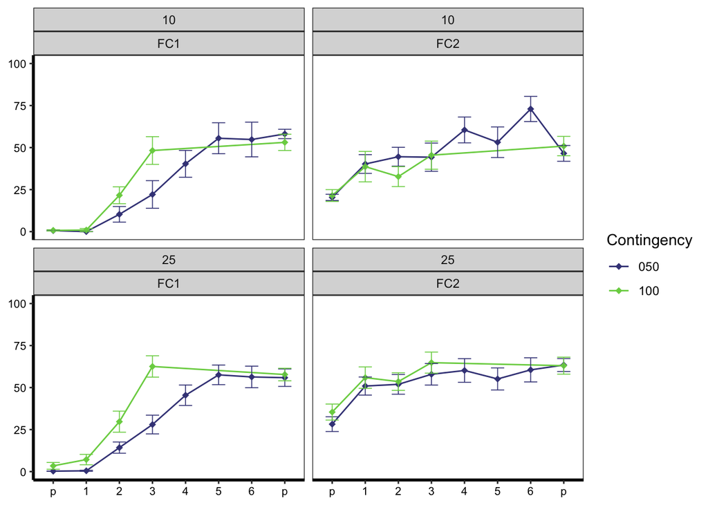

```r
Fig1.B1 <-
  ggplot(FC_ave_1.1, aes(x=interaction(Component.Name), y=group_mean_freezing, group=Contingency, color=Contingency)) +
  scale_color_viridis_d(begin=0.2, end=0.8) +
  scale_fill_viridis_d(begin=0.2, end=0.8) +
  facet_wrap(~CS_dur * Exp_Type) +
  geom_line() +
  geom_point(shape=18, size=2) +
  geom_errorbar(aes(ymin = group_mean_freezing-se, ymax = group_mean_freezing+se, width = 0.4), linewidth=0.3) +
  ylim(0,100) +
  scale_x_discrete(limits=c("pre-tone", "tone 01", "tone 02", "tone 03",  "tone 04", "tone 05", "tone 06","post-tone"),
                   labels=c("p", "1", "2", "3", "4", "5", "6", "p")) +
  labs(
    x = "CS Time",
    y = "% Time Freezing") +
  theme_bw() +
  theme(
        plot.background = element_blank(),
        plot.title = element_blank(),
        panel.grid.major = element_blank(),
        panel.grid.minor = element_blank(),
        axis.text.x = element_text(size = 8, color="black"),
        axis.text.y = element_text(size = 8, color="black"),
        axis.title.x = element_blank(),
        axis.title.y = element_blank(),
        axis.line.x = element_line(color="black", linewidth = 1),
        axis.line.y = element_line(color="black", linewidth = 1))

Fig1.B1
```

```r
# ggsave("Fig1B1.pdf", plot = Fig1.B1, width = 2, height = 2, units = "in")
```

### B1 - Stats

Sex was originally in the statistical model; however, considering lack of consistent sex-specific effects observed, it was dropped from models. Nonetheless, individuals points are plotted showing sex whenever possible. WHere individual data points are not present, see the Supplementary figs that segregate the acquisition curves by sex.

The acquisition data was analyzed using separate models for within-session acquisition (i.e. comparing changes in freezing by CS across one training session) and between-session (i.e. comparing differences in freezing per training session).

Model 1.B1 (Fig1B-1) - “within session learning”. This uses only CS paired with US (i.e. 3 total, CS 1-3 for 100% Contingency, and CS1,3,6 for 50% Contingency). Each FC day was analyzed using a separate ANOVA.

```r
# Analysis of FC1 Data
m1b1_FC1 <- FC_id_1.1  %>%
   filter(str_detect(CS, "tone 01|tone 02|tone 03") &
          Exp_Type == "FC1") %>%
  aov_ez(id = "id",
         dv = "mean_freezing",
         between = c("Contingency", "CS_dur"),
         within = c("CS"),
         data = .)
```

```
## Converting to factor: Contingency, CS_dur
```

```
## Contrasts set to contr.sum for the following variables: Contingency, CS_dur
```

```r
#ANOVA table
nice_m1b1_FC1 <-nice(m1b1_FC1)
kable(nice_m1b1_FC1, caption = '<b>Figure 1.B1: FC1 Main FX</b>') %>%
  kable_styling(bootstrap_options = "striped", full_width = F, position = "left")
```

**Figure 1.B1: FC1 Main FX**

| Effect | df | MSE | F | ges | p.value |
| --- | --- | --- | --- | --- | --- |
| Contingency | 1, 59 | 756.29 | 0.12 | <.001 | .732 |
| CS_dur | 1, 59 | 756.29 | 2.19 | .017 | .144 |
| Contingency:CS_dur | 1, 59 | 756.29 | 0.71 | .006 | .404 |
| CS | 1.75, 103.49 | 476.42 | 101.73 *** | .475 | <.001 |
| Contingency:CS | 1.75, 103.49 | 476.42 | 0.16 | .001 | .828 |
| CS_dur:CS | 1.75, 103.49 | 476.42 | 0.21 | .002 | .785 |
| Contingency:CS_dur:CS | 1.75, 103.49 | 476.42 | 0.26 | .002 | .744 |

```r
#Post-hoc analyses
n1b1.1_FC1 <- emmeans(m1b1_FC1, ~ CS)
```

```
## NOTE: Results may be misleading due to involvement in interactions
```

```r
n1b1.1_FC1_pairs<- pairs(n1b1.1_FC1, simple="each")
kable(n1b1.1_FC1_pairs[1], caption = '<b>Figure 1.B1: Simple contrasts for CS</b>')
```

**Figure 1.B1: Simple contrasts for CS**

| contrast | estimate | SE | df | t.ratio | p.value |
| --- | --- | --- | --- | --- | --- |
| tone.01 - tone.02 | -23.22080 | 3.031412 | 59 | -7.660061 | 0 |
| tone.01 - tone.03 | -53.34744 | 3.844808 | 59 | -13.875188 | 0 |
| tone.02 - tone.03 | -30.12664 | 4.269137 | 59 | -7.056846 | 0 |

```r
#######################
# Analysis of FC2 Data
m1b1_FC2 <- FC_id_1.1  %>%
   filter(str_detect(CS, "tone 01|tone 02|tone 03") &
          Exp_Type == "FC2") %>%
  aov_ez(id = "id",
         dv = "mean_freezing",
         between = c("Contingency", "CS_dur"),
         within = c("CS"),
         data = .)
```

```
## Converting to factor: Contingency, CS_dur
## Contrasts set to contr.sum for the following variables: Contingency, CS_dur
```

```r
#ANOVA table
nice_m1b1_FC2 <-nice(m1b1_FC2)
kable(nice_m1b1_FC2, caption = '<b>Figure 1.B1: FC2 Main FX</b>') %>%
  kable_styling(bootstrap_options = "striped", full_width = F, position = "left")
```

**Figure 1.B1: FC2 Main FX**

| Effect | df | MSE | F | ges | p.value |
| --- | --- | --- | --- | --- | --- |
| Contingency | 1, 59 | 974.02 | 1.61 | .012 | .209 |
| CS_dur | 1, 59 | 974.02 | 6.11 * | .044 | .016 |
| Contingency:CS_dur | 1, 59 | 974.02 | 2.64 | .020 | .110 |
| CS | 1.84, 108.30 | 650.13 | 6.69 ** | .059 | .002 |
| Contingency:CS | 1.84, 108.30 | 650.13 | 1.18 | .011 | .308 |
| CS_dur:CS | 1.84, 108.30 | 650.13 | 1.29 | .012 | .279 |
| Contingency:CS_dur:CS | 1.84, 108.30 | 650.13 | 1.29 | .012 | .279 |

```r
#Post-hoc analyses
#Contrast for CS
n1b1.1_FC2 <- emmeans(m1b1_FC2, ~ CS)
```

```
## NOTE: Results may be misleading due to involvement in interactions
```

```r
n1b1.1_pairs_FC2<- pairs(n1b1.1_FC2, simple="each")
kable(n1b1.1_pairs_FC2[1], caption = '<b>Figure 1.B1: Simple contrasts for CS Day</b>')
```

**Figure 1.B1: Simple contrasts for CS Day**

| contrast | estimate | SE | df | t.ratio | p.value |
| --- | --- | --- | --- | --- | --- |
| tone.01 - tone.02 | -0.6869868 | 3.791434 | 59 | -0.1811945 | 0.9820686 |
| tone.01 - tone.03 | -14.5264803 | 4.617650 | 59 | -3.1458596 | 0.0072149 |
| tone.02 - tone.03 | -13.8394934 | 4.956035 | 59 | -2.7924526 | 0.0190136 |

```r
#Contrast for CS duration
n1b1.2_FC2 <- emmeans(m1b1_FC2, ~ CS_dur)
```

```
## NOTE: Results may be misleading due to involvement in interactions
```

```r
n1b1.2_pairs_FC2<- pairs(n1b1.2_FC2, simple="each")
kable(n1b1.2_pairs_FC2[1], caption = '<b>Figure 1B-1: Simple contrasts for CS durationy</b>')
```

**Figure 1B-1: Simple contrasts for CS durationy**

| contrast | estimate | SE | df | t.ratio | p.value |
| --- | --- | --- | --- | --- | --- |
| CS_dur10 - CS_dur25 | -11.55753 | 4.675297 | 59 | -2.472042 | 0.0163379 |

## B2. Between-Session FC

### B2 - Dataframe

```r
#Create a dataframe with CS freezing averaged for each experimental group
FC_id_1.2 <- FC_id_1.1 %>%
  filter(str_detect(Component.Name, "pre-tone|post-tone", negate=TRUE)) %>%
  group_by(id, Sex, CS_dur, Contingency, Exp_Type) %>%
  summarize(mean_freezing=mean(mean_freezing), n=n(),
            se=sd(mean_freezing/sqrt(n())))
```

```
## can override using the `.groups` argument.
```

```r
FC_ave_1.2 <- FC_id_1.2 %>%
  group_by(CS_dur, Contingency, Exp_Type) %>%
  summarize(group_mean_freezing=mean(mean_freezing), n=n(),
            se=sd(mean_freezing/sqrt(n())))
```

### B2 - Graph

Between-sessions comparison: Plot data by group, averaging all CS per FC day

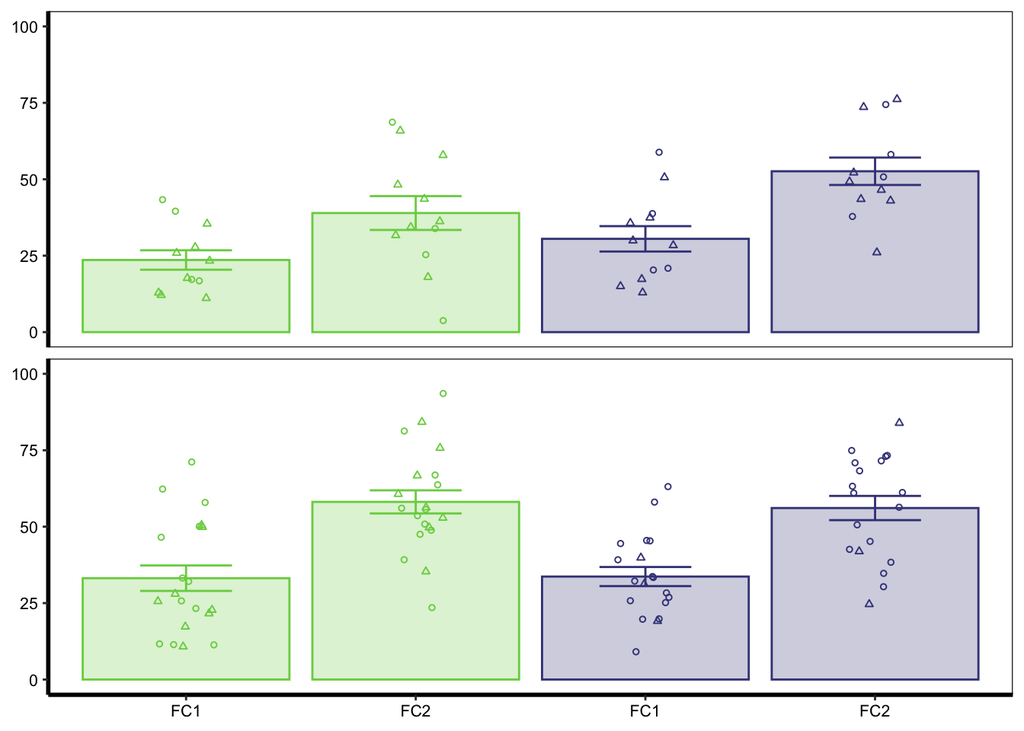

```r
Fig1.B2 <- ggplot(FC_ave_1.2,
  aes(x=interaction(Exp_Type,Contingency),
      y=group_mean_freezing,
      group = Contingency, fill= Contingency, color=Contingency)) +
  scale_color_viridis_d(begin=0.2, end=0.8) +
  scale_fill_viridis_d(begin=0.2, end=0.8) +
  facet_wrap(~CS_dur, ncol=1) +
  geom_errorbar(aes(ymin = group_mean_freezing-se, ymax = group_mean_freezing+se), width=0.4) +
  geom_bar(stat="identity", alpha=0.25) +
  geom_point(
    data=FC_id_1.2,
    aes(x=interaction(Exp_Type, Contingency), y=mean_freezing, shape=Sex),position = position_jitterdodge(jitter.height=0, jitter.width=0.25, dodge.width = 0.8), size=1) +
  scale_shape(solid = FALSE) +
   scale_x_discrete(limits=c("FC1.100","FC2.100", "FC1.050", "FC2.050"),
                    labels= c("FC1", "FC2", "FC1", "FC2")) +
  ylim(0,100) +
  theme_bw() +
  theme(legend.position = "none",
        strip.background = element_blank(),
        strip.text = element_blank(),
        plot.background = element_blank(),
        axis.title.x = element_blank(),
        axis.title.y = element_blank(),
        plot.title = element_blank(),
        panel.grid.major = element_blank(),
        panel.grid.minor = element_blank(),
        axis.text.x = element_text(size = 8, color="black"),
        axis.text.y = element_text(size = 8, color="black"),
        axis.line.x = element_line(color="black", linewidth = 1),
        axis.line.y = element_line(color="black", linewidth = 1))+
  labs(
    x = "CS Time",
    y = "% Time Freezing")

Fig1.B2
```

```r
 # ggsave("Fig1B2.pdf", plot = Fig1.B2, width = 1, height = 2, units = "in")
```

### B2 - Stats

Model 1.B2 (Fig1B-2) - “Between-session learning”. This uses all CS averaged per session (i.e. 3 total for 100% Contingency, and 6 for 50% Contingency) and compares freezing across FC training session.

```r
m1b2 <- FC_id_1.2 %>%
  aov_ez(id = "id",
         dv = "mean_freezing",
         between = c("Contingency", "CS_dur"),
         within = c("Exp_Type"),
         data = .)
```

```
## Converting to factor: Contingency, CS_dur
```

```
## Contrasts set to contr.sum for the following variables: Contingency, CS_dur
```

```r
#ANOVA table
nice_m1b2  <-nice(m1b2 )
kable(nice_m1b2, caption = '<b>Figure 1.B2: Main FX</b>') %>%
  kable_styling(bootstrap_options = "striped", full_width = F, position = "left")
```

**Figure 1.B2: Main FX**

| Effect | df | MSE | F | ges | p.value |
| --- | --- | --- | --- | --- | --- |
| Contingency | 1, 59 | 355.14 | 1.91 | .021 | .172 |
| CS_dur | 1, 59 | 355.14 | 6.54 * | .070 | .013 |
| Contingency:CS_dur | 1, 59 | 355.14 | 2.54 | .028 | .116 |
| Exp_Type | 1, 59 | 171.02 | 78.14 *** | .301 | <.001 |
| Contingency:Exp_Type | 1, 59 | 171.02 | 0.19 | .001 | .663 |
| CS_dur:Exp_Type | 1, 59 | 171.02 | 1.07 | .006 | .306 |
| Contingency:CS_dur:Exp_Type | 1, 59 | 171.02 | 0.94 | .005 | .338 |

## C. FC Recall

Recall was operationally defined as the proportion of time freezing between two CS epochs: (1) CS freezing on FC Day 2 and (2) the first four CS presentations on Extinction Day 1.

### C - Dataframe

```r
E1_Session1_id_1 <- df %>%
  filter(str_detect(Exp_Type, "E1"),
         str_detect(Exp_Type, "ER", negate = TRUE),
         str_detect(Trials, "3"),
         str_detect(Component.Name,  "tone 01|tone 02|tone 03|tone 04")) %>%
  group_by(id, CS_dur, Contingency, Exp_Type, Sex) %>%
  summarize(mean_freezing=mean(Pct.Component.Time.Freezing), n=n(),
            se=sd(Pct.Component.Time.Freezing/sqrt(n())))
```

```
## You can override using the `.groups` argument.
```

```r
E1_Session1_ave_1 <- E1_Session1_id_1 %>%
  group_by(CS_dur, Contingency, Exp_Type) %>%
  summarize(group_mean_freezing=mean(mean_freezing), n=n(),
            se=sd(mean_freezing/sqrt(n())))
FC2_id_1 <- df %>%
  filter(str_detect(Component.Name, "pre-tone|post-tone", negate = TRUE),
         str_detect(Exp_Type, "FC2"),
         str_detect(Trials, "3")) %>%
  group_by(id, CS_dur, Contingency, Exp_Type, Sex) %>%
  summarize(mean_freezing=mean(Pct.Component.Time.Freezing), n=n(),
            se=sd(Pct.Component.Time.Freezing/sqrt(n())))
```

```
## You can override using the `.groups` argument.
```

```r
FC2_ave_1 <- FC2_id_1 %>%
  group_by(CS_dur, Contingency, Exp_Type) %>%
  summarize(group_mean_freezing=mean(mean_freezing), n=n(),
            se=sd(mean_freezing/sqrt(n())))
E1_FC2_id_1 <-rbind(E1_Session1_id_1, FC2_id_1)

E1_FC2_ave_1 <-rbind(E1_Session1_ave_1, FC2_ave_1)
```

### C - Graph

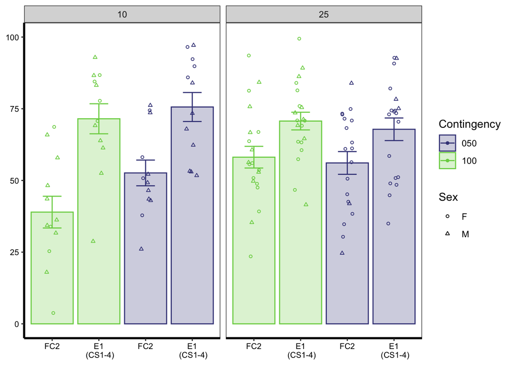

```r
Fig1C <- ggplot(
  E1_FC2_ave_1,
  aes(x=interaction(Exp_Type,Contingency),
      y=group_mean_freezing,
      group = Contingency, fill= Contingency, color=Contingency)) +
  scale_color_viridis_d(begin=0.2, end=0.8) +
  scale_fill_viridis_d(begin=0.2, end=0.8) +
  facet_wrap(~CS_dur) +
  geom_errorbar(aes(ymin = group_mean_freezing-se, ymax = group_mean_freezing+se), width=0.4) +
  geom_bar(stat="identity", alpha=0.25) +
  geom_point(
    data=E1_FC2_id_1,
    aes(x=interaction(Exp_Type, Contingency), y=mean_freezing, shape=Sex),position = position_jitterdodge(jitter.height=0, jitter.width=0.25, dodge.width = 0.8), size=1) +
  scale_shape(solid = FALSE) +
   scale_x_discrete(limits=c("FC2.100", "E1.100", "FC2.050", "E1.050"),
                    labels= c("FC2", "E1\n (CS1-4)", "FC2", "E1\n (CS1-4)")) +
  ylim(0,100) +
  theme_bw() +
  theme(
        plot.background = element_blank(),
        axis.title.x = element_blank(),
        axis.title.y = element_blank(),
        plot.title = element_blank(),
        panel.grid.major = element_blank(),
        panel.grid.minor = element_blank(),
        axis.text.x = element_text(size = 8, color="black"),
        axis.text.y = element_text(size = 8, color="black"),
        axis.line.x = element_line(color="black", linewidth = 1),
        axis.line.y = element_line(color="black", linewidth = 1))+
  labs(
    x = "CS Time",
    y = "% Time Freezing")

Fig1C
```

```r
# ggsave("Fig1C.pdf", plot = Fig1C, width = 2, height = 2, units = "in")
```

### C - Stats

Model 1.C - Exp_Type in this model refers to each of the two CS epochs described above

```r
m1c <- E1_FC2_id_1 %>%
  aov_ez(id = "id",
         dv = "mean_freezing",
         between = c("Contingency", "CS_dur"),
         within = "Exp_Type",
         data = .)
```

```
## Converting to factor: Contingency, CS_dur
```

```
## Contrasts set to contr.sum for the following variables: Contingency, CS_dur
```

```r
#ANOVA table
nice_m1c <-nice(m1c)
kable(nice_m1c, caption = '<b>Figure 1C: Main FX</b>') %>%
  kable_styling(bootstrap_options = "striped", full_width = F, position = "left", font_size = 14)
```

**Figure 1C: Main FX**

| Effect | df | MSE | F | ges | p.value |
| --- | --- | --- | --- | --- | --- |
| Contingency | 1, 59 | 345.42 | 0.89 | .009 | .348 |
| CS_dur | 1, 59 | 345.42 | 1.06 | .011 | .307 |
| Contingency:CS_dur | 1, 59 | 345.42 | 2.76 | .028 | .102 |
| Exp_Type | 1, 59 | 221.07 | 53.57 *** | .262 | <.001 |
| Contingency:Exp_Type | 1, 59 | 221.07 | 0.91 | .006 | .344 |
| CS_dur:Exp_Type | 1, 59 | 221.07 | 8.18 ** | .051 | .006 |
| Contingency:CS_dur:Exp_Type | 1, 59 | 221.07 | 0.64 | .004 | .428 |

```r
#Post-hoc analyses
n1c <- emmeans(m1c, ~ Exp_Type * CS_dur)

#Contrast for CS x FC Day interaction
n1c_pairs<- pairs(n1c, simple="each")
n1c_pairs
```

```
## $`simple contrasts for Exp_Type`
## CS_dur = 10:
##  contrast estimate   SE df t.ratio p.value
##  E1 - FC2     27.8 4.29 59   6.470  <.0001
##
## CS_dur = 25:
##  contrast estimate   SE df t.ratio p.value
##  E1 - FC2     12.2 3.37 59   3.611  0.0006
##
## Results are averaged over the levels of: Contingency
##
## $`simple contrasts for CS_dur`
## Exp_Type = E1:
##  contrast            estimate   SE df t.ratio p.value
##  CS_dur10 - CS_dur25     4.29 4.26 59   1.006  0.3187
##
## Exp_Type = FC2:
##  contrast            estimate   SE df t.ratio p.value
##  CS_dur10 - CS_dur25   -11.32 4.47 59  -2.533  0.0140
##
## Results are averaged over the levels of: Contingency
```

```r
kable(n1c_pairs[], caption = '<b>Figure 1C: Simple contrasts for CE-Epoch x CS durationy</b>')
```

**Figure 1C: Simple contrasts for CE-Epoch x CS durationy**

| contrast | CS_dur | estimate | SE | df | t.ratio | p.value |
| --- | --- | --- | --- | --- | --- | --- |
| E1 - FC2 | 10 | 27.76924 | 4.292181 | 59 | 6.469727 | 0.0000000 |
| E1 - FC2 | 25 | 12.16404 | 3.368171 | 59 | 3.611467 | 0.0006298 |

| contrast | Exp_Type | estimate | SE | df | t.ratio | p.value |
| --- | --- | --- | --- | --- | --- | --- |
| CS_dur10 - CS_dur25 | E1 | 4.286239 | 4.262484 | 59 | 1.005573 | 0.3187274 |
| CS_dur10 - CS_dur25 | FC2 | -11.318960 | 4.468806 | 59 | -2.532883 | 0.0139921 |

## D. Extinction Acquisition

## D1. Within-Session Extinction

### D1 - Dataframe

To evaluate the effect of partial reinforcement on fear extinction acquisition, mice were exposed to 12 unreinforced CS presentations for three consecutive days (E1, E2, E3) in a novel context (Context B). Percent time freezing was averaged in bins composed of 3CS presentations.

```r
EXT_bin_id_1 <- df %>%
  filter(str_detect(Exp_Type, "E"),
         str_detect(Trials, "3"),
         str_detect(Experiment, "ER", negate = TRUE)) %>%
  group_by(Exp_Type, id, Sex, CS_dur, Contingency, Bin) %>%
  summarize(mean_freezing=mean(Pct.Component.Time.Freezing), n=n(),
            se=sd(Pct.Component.Time.Freezing/sqrt(n())))
```

```
## 'Contingency'. You can override using the `.groups` argument.
```

```r
EXT_bin_ave_1 <- EXT_bin_id_1 %>%
  group_by(Exp_Type, Bin, CS_dur, Contingency) %>%
  summarize(group_mean_freezing=mean(mean_freezing), n=n(),
            se=sd(mean_freezing/sqrt(n())))
EXT_bin_ave_1$Bin <- factor(EXT_bin_ave_1$Bin, levels = c("Pre", "1", "2", "3", "4", "Post"))
```

### D1 - Graph

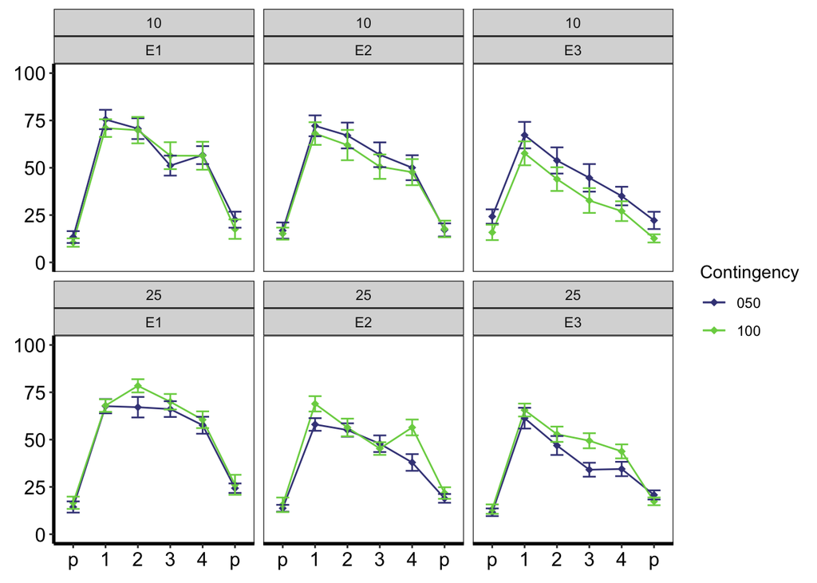

```r
Fig1.D1 <-
  ggplot(
  data = subset(EXT_bin_ave_1, !is.na(Bin)),
  aes(x=interaction(Bin),
      y=group_mean_freezing,
      group = Contingency, color= Contingency, fill=Contingency)) +
  scale_color_viridis_d(begin=0.2, end=0.8) +
  scale_fill_viridis_d(begin=0.2, end=0.8) +
  facet_wrap(~CS_dur * Exp_Type) +
  geom_line() +
  geom_point(shape=18, size=2) +
  scale_shape(solid = FALSE) +
  geom_errorbar(aes(ymin = group_mean_freezing-se, ymax = group_mean_freezing+se), width=0.4) +
  scale_x_discrete(limits=c("Pre", "1", "2", "3", "4", "Post"),
                   labels=c("p", "1", "2", "3", "4", "p")) +
  ylim(0,100) +
  labs(x = "Bin", y = "% Time Freezing") +
  theme_bw() +
    theme(
        plot.background = element_blank(),
        plot.title = element_text(size = 18,face="bold.italic", hjust=0.5),
        panel.grid.major = element_blank(),
        panel.grid.minor = element_blank(),
        axis.text.x = element_text(size = 12, color="black"),
        axis.text.y = element_text(size = 12, color="black"),
        axis.title.x = element_text(size = 0, face= "bold"),
        axis.title.y = element_text(size = 0, face="bold"),
        axis.line.x = element_line(color="black", linewidth = 1),
        axis.line.y = element_line(color="black", linewidth = 1))

Fig1.D1
```

```r
# ggsave("Fig1D1.pdf", plot = Fig1.D1, width = 2.5, height = 2.5, units = "in")
```

### D1 - Stats

Model 1.D1 (Fig1D-1) - The acquisition data was analyzed using separate models for within-session acquisition (i.e. comparing changes in freezing by CS across one training session) and between-session (i.e. comparing differences in freezing per training session).

```r
#FE1 - Mean freezing analysis
m1.d1.FE1 <- EXT_bin_id_1 %>%
  filter(str_detect(Bin, "Pre|Post", negate = TRUE)) %>%
   filter(Exp_Type == "E1") %>%
  aov_ez(id = "id",
         dv = "mean_freezing",
         between = c("Contingency", "CS_dur"),
         within = c("Bin"),
         data = .)
```

```
## Converting to factor: Contingency, CS_dur
```

```
## Contrasts set to contr.sum for the following variables: Contingency, CS_dur
```

```r
##ANOVA table
nice_m1.d1.FE1 <-nice(m1.d1.FE1)
kable(nice_m1.d1.FE1, caption = '<b>Figure 1.D1-E1: Main FX</b>') %>%
  kable_styling(bootstrap_options = "striped", full_width = F, position = "left")
```

**Figure 1.D1-E1: Main FX**

| Effect | df | MSE | F | ges | p.value |
| --- | --- | --- | --- | --- | --- |
| Contingency | 1, 59 | 948.88 | 0.32 | .003 | .576 |
| CS_dur | 1, 59 | 948.88 | 0.76 | .008 | .387 |
| Contingency:CS_dur | 1, 59 | 948.88 | 0.35 | .004 | .558 |
| Bin | 2.68, 157.83 | 200.40 | 15.70 *** | .088 | <.001 |
| Contingency:Bin | 2.68, 157.83 | 200.40 | 0.95 | .006 | .409 |
| CS_dur:Bin | 2.68, 157.83 | 200.40 | 5.47 ** | .032 | .002 |
| Contingency:CS_dur:Bin | 2.68, 157.83 | 200.40 | 0.65 | .004 | .567 |

```r
##Post-hoc analyses
n1.d1.FE1 <- emmeans(m1.d1.FE1, ~ CS_dur * Bin)
n1bd.1_pairs_FE1<- pairs(n1.d1.FE1, simple="each")

##Simple contrasts for Bin
kable(n1bd.1_pairs_FE1[], caption = '<b>Figure 1.D1-E1: Simple Contrasts CS bin by CS duration</b>')
```

**Figure 1.D1-E1: Simple Contrasts CS bin by CS duration**

| contrast | Bin | estimate | SE | df | t.ratio | p.value |
| --- | --- | --- | --- | --- | --- | --- |
| CS_dur10 - CS_dur25 | X1 | 5.389757 | 4.194087 | 59 | 1.2850847 | 0.2037847 |
| CS_dur10 - CS_dur25 | X2 | -2.508703 | 5.344962 | 59 | -0.4693585 | 0.6405434 |
| CS_dur10 - CS_dur25 | X3 | -14.291833 | 5.087166 | 59 | -2.8093900 | 0.0067223 |
| CS_dur10 - CS_dur25 | X4 | -2.533811 | 5.285669 | 59 | -0.4793738 | 0.6334449 |

| contrast | CS_dur | estimate | SE | df | t.ratio | p.value |
| --- | --- | --- | --- | --- | --- | --- |
| X1 - X2 | 10 | 2.9595833 | 2.905524 | 59 | 1.0186056 | 0.7392539 |
| X1 - X3 | 10 | 19.4522222 | 3.983820 | 59 | 4.8828064 | 0.0000485 |
| X1 - X4 | 10 | 16.7080556 | 3.974812 | 59 | 4.2034832 | 0.0005126 |
| X2 - X3 | 10 | 16.4926389 | 4.186570 | 59 | 3.9394159 | 0.0012224 |
| X2 - X4 | 10 | 13.7484722 | 4.055032 | 59 | 3.3904723 | 0.0066761 |
| X3 - X4 | 10 | -2.7441667 | 3.907608 | 59 | -0.7022624 | 0.8957873 |
| X1 - X2 | 25 | -4.9388772 | 2.280030 | 59 | -2.1661454 | 0.1447652 |
| X1 - X3 | 25 | -0.2293684 | 3.126193 | 59 | -0.0733699 | 0.9998567 |
| X1 - X4 | 25 | 8.7844868 | 3.119125 | 59 | 2.8163308 | 0.0325196 |
| X2 - X3 | 25 | 4.7095088 | 3.285296 | 59 | 1.4335114 | 0.4838958 |
| X2 - X4 | 25 | 13.7233640 | 3.182075 | 59 | 4.3127096 | 0.0003548 |
| X3 - X4 | 25 | 9.0138553 | 3.066388 | 59 | 2.9395673 | 0.0235924 |

```r
###### FE2 ############
m1.d1.FE2 <- EXT_bin_id_1 %>%
  filter(str_detect(Bin, "Pre|Post", negate = TRUE)) %>%
   filter(Exp_Type == "E2") %>%
  aov_ez(id = "id",
         dv = "mean_freezing",
         between = c("Contingency", "CS_dur"),
         within = c("Bin"),
         data = .)
```

```
## Converting to factor: Contingency, CS_dur
## Contrasts set to contr.sum for the following variables: Contingency, CS_dur
```

```r
#ANOVA table
nice_m1.d1.FE2 <-nice(m1.d1.FE2)
kable(nice_m1.d1.FE2, caption = '<b>Figure 1.D1-E2: Main FX</b>') %>%
  kable_styling(bootstrap_options = "striped", full_width = F, position = "left")
```

**Figure 1.D1-E2: Main FX**

| Effect | df | MSE | F | ges | p.value |
| --- | --- | --- | --- | --- | --- |
| Contingency | 1, 59 | 1101.95 | 0.09 | .001 | .764 |
| CS_dur | 1, 59 | 1101.95 | 1.99 | .023 | .164 |
| Contingency:CS_dur | 1, 59 | 1101.95 | 1.78 | .021 | .188 |
| Bin | 2.61, 154.01 | 183.45 | 28.67 *** | .128 | <.001 |
| Contingency:Bin | 2.61, 154.01 | 183.45 | 2.89 * | .015 | .045 |
| CS_dur:Bin | 2.61, 154.01 | 183.45 | 0.88 | .004 | .442 |
| Contingency:CS_dur:Bin | 2.61, 154.01 | 183.45 | 1.44 | .007 | .238 |

```r
#Post-hoc analyses
#Post-hoc model #1
n1.d1.FE2 <- emmeans(m1.d1.FE2, ~ Contingency * Bin)
n1.d1.FE2_pairs<- pairs(n1.d1.FE2, simple="each")

# #Simple contrasts for Contingency (no sig effects)
# kable(n1.d1.FE2_pairs[1], caption = '<b>Figure 1.D1-E2: Simple Contrasts by CS bin</b>')

kable(n1.d1.FE2_pairs[], caption = '<b>Figure 1.D1-E2: Simple Contrasts by CS bin</b>')
```

**Figure 1.D1-E2: Simple Contrasts by CS bin**

| contrast | Bin | estimate | SE | df | t.ratio | p.value |
| --- | --- | --- | --- | --- | --- | --- |
| Contingency050 - Contingency100 | X1 | -3.411162 | 4.631031 | 59 | -0.7365881 | 0.4642917 |
| Contingency050 - Contingency100 | X2 | 1.863092 | 5.573547 | 59 | 0.3342741 | 0.7393581 |
| Contingency050 - Contingency100 | X3 | 4.422017 | 5.005925 | 59 | 0.8833567 | 0.3806289 |
| Contingency050 - Contingency100 | X4 | -8.076155 | 5.372004 | 59 | -1.5033786 | 0.1380757 |

| contrast | Contingency | estimate | SE | df | t.ratio | p.value |
| --- | --- | --- | --- | --- | --- | --- |
| X1 - X2 | 050 | 4.028662 | 2.805619 | 59 | 1.435927 | 0.4824273 |
| X1 - X3 | 050 | 12.727098 | 3.126411 | 59 | 4.070833 | 0.0007962 |
| X1 - X4 | 050 | 21.102909 | 3.731540 | 59 | 5.655282 | 0.0000028 |
| X2 - X3 | 050 | 8.698436 | 3.108977 | 59 | 2.797845 | 0.0340905 |
| X2 - X4 | 050 | 17.074247 | 3.817822 | 59 | 4.472248 | 0.0002055 |
| X3 - X4 | 050 | 8.375811 | 3.049411 | 59 | 2.746698 | 0.0387916 |
| X1 - X2 | 100 | 9.302917 | 2.778335 | 59 | 3.348379 | 0.0075522 |
| X1 - X3 | 100 | 20.560278 | 3.096007 | 59 | 6.640901 | 0.0000001 |
| X1 - X4 | 100 | 16.437917 | 3.695252 | 59 | 4.448389 | 0.0002232 |
| X2 - X3 | 100 | 11.257361 | 3.078743 | 59 | 3.656480 | 0.0029913 |
| X2 - X4 | 100 | 7.135000 | 3.780695 | 59 | 1.887219 | 0.2445785 |
| X3 - X4 | 100 | -4.122361 | 3.019757 | 59 | -1.365130 | 0.5259493 |

```r
#Post-hoc model
n2.d1.FE2 <- emmeans(m1.d1.FE2, ~ Contingency * Bin)
n2.d1.FE2_pairs<- pairs(n2.d1.FE2, simple="each")

# #Simple contrasts
 kable(n2.d1.FE2_pairs[], caption = '<b>Figure 1.D1-E2: Simple Contrasts CS bin by Contingency</b>')
```

**Figure 1.D1-E2: Simple Contrasts CS bin by Contingency**

| contrast | Bin | estimate | SE | df | t.ratio | p.value |
| --- | --- | --- | --- | --- | --- | --- |
| Contingency050 - Contingency100 | X1 | -3.411162 | 4.631031 | 59 | -0.7365881 | 0.4642917 |
| Contingency050 - Contingency100 | X2 | 1.863092 | 5.573547 | 59 | 0.3342741 | 0.7393581 |
| Contingency050 - Contingency100 | X3 | 4.422017 | 5.005925 | 59 | 0.8833567 | 0.3806289 |
| Contingency050 - Contingency100 | X4 | -8.076155 | 5.372004 | 59 | -1.5033786 | 0.1380757 |

| contrast | Contingency | estimate | SE | df | t.ratio | p.value |
| --- | --- | --- | --- | --- | --- | --- |
| X1 - X2 | 050 | 4.028662 | 2.805619 | 59 | 1.435927 | 0.4824273 |
| X1 - X3 | 050 | 12.727098 | 3.126411 | 59 | 4.070833 | 0.0007962 |
| X1 - X4 | 050 | 21.102909 | 3.731540 | 59 | 5.655282 | 0.0000028 |
| X2 - X3 | 050 | 8.698436 | 3.108977 | 59 | 2.797845 | 0.0340905 |
| X2 - X4 | 050 | 17.074247 | 3.817822 | 59 | 4.472248 | 0.0002055 |
| X3 - X4 | 050 | 8.375811 | 3.049411 | 59 | 2.746698 | 0.0387916 |
| X1 - X2 | 100 | 9.302917 | 2.778335 | 59 | 3.348379 | 0.0075522 |
| X1 - X3 | 100 | 20.560278 | 3.096007 | 59 | 6.640901 | 0.0000001 |
| X1 - X4 | 100 | 16.437917 | 3.695252 | 59 | 4.448389 | 0.0002232 |
| X2 - X3 | 100 | 11.257361 | 3.078743 | 59 | 3.656480 | 0.0029913 |
| X2 - X4 | 100 | 7.135000 | 3.780695 | 59 | 1.887219 | 0.2445785 |
| X3 - X4 | 100 | -4.122361 | 3.019757 | 59 | -1.365130 | 0.5259493 |

```r
###### FE3 ############
m1.d1.FE3 <- EXT_bin_id_1 %>%
  filter(str_detect(Bin, "Pre|Post", negate = TRUE)) %>%
   filter(Exp_Type == "E3") %>%
  aov_ez(id = "id",
         dv = "mean_freezing",
         between = c("Contingency", "CS_dur"),
         within = c("Bin"),
         data = .)
```

```
## Converting to factor: Contingency, CS_dur
## Contrasts set to contr.sum for the following variables: Contingency, CS_dur
```

```r
#ANOVA table
nice_m1.d1.FE3 <-nice(m1.d1.FE3)
kable(nice_m1.d1.FE3, caption = '<b>Figure 1.D1-E3: Main FX</b>') %>%
  kable_styling(bootstrap_options = "striped", full_width = F, position = "left")
```

**Figure 1.D1-E3: Main FX**

| Effect | df | MSE | F | ges | p.value |
| --- | --- | --- | --- | --- | --- |
| Contingency | 1, 59 | 1107.89 | 0.02 | <.001 | .895 |
| CS_dur | 1, 59 | 1107.89 | 0.58 | .007 | .451 |
| Contingency:CS_dur | 1, 59 | 1107.89 | 4.62 * | .052 | .036 |
| Bin | 2.81, 165.68 | 166.30 | 57.00 *** | .223 | <.001 |
| Contingency:Bin | 2.81, 165.68 | 166.30 | 0.41 | .002 | .736 |
| CS_dur:Bin | 2.81, 165.68 | 166.30 | 1.06 | .005 | .363 |
| Contingency:CS_dur:Bin | 2.81, 165.68 | 166.30 | 0.86 | .004 | .459 |

```r
#Post-hoc analyses
#Post-hoc model #1
n1.d1.FE3 <- emmeans(m1.d1.FE3, ~ Bin)
n1.d1.FE3_pairs<- pairs(n1.d1.FE3, simple="each")

#Simple contrasts for Bin
kable(n1.d1.FE3_pairs[], caption = '<b>Figure 1.D1-E3: Simple Contrasts by CS bin</b>')
```

**Figure 1.D1-E3: Simple Contrasts by CS bin**

| contrast | estimate | SE | df | t.ratio | p.value |
| --- | --- | --- | --- | --- | --- |
| X1 - X2 | 13.564143 | 2.119168 | 59 | 6.400691 | 0.0000002 |
| X1 - X3 | 22.742757 | 2.331385 | 59 | 9.755040 | 0.0000000 |
| X1 - X4 | 27.857716 | 2.452714 | 59 | 11.357915 | 0.0000000 |
| X2 - X3 | 9.178613 | 1.904834 | 59 | 4.818590 | 0.0000610 |
| X2 - X4 | 14.293573 | 2.455459 | 59 | 5.821140 | 0.0000015 |
| X3 - X4 | 5.114960 | 2.416614 | 59 | 2.116581 | 0.1597778 |

```r
#Post-hoc model #2
n2.d1.FE3 <- emmeans(m1.d1.FE3, ~ Contingency * CS_dur)
n2.d1.FE3_pairs<- pairs(n2.d1.FE3, simple="each")

#One sig effect. Not pertinent to hypothesis tested.
kable(n2.d1.FE3_pairs[], caption = '<b>Figure 1.D1-E3: Simple Contrasts Contingency by CS_duration</b>')
```

**Figure 1.D1-E3: Simple Contrasts Contingency by CS_duration**

| contrast | CS_dur | estimate | SE | df | t.ratio | p.value |
| --- | --- | --- | --- | --- | --- | --- |
| Contingency050 - Contingency100 | 10 | 9.856181 | 6.794257 | 59 | 1.450663 | 0.1521696 |
| Contingency050 - Contingency100 | 25 | -8.712895 | 5.331607 | 59 | -1.634197 | 0.1075429 |

| contrast | Contingency | estimate | SE | df | t.ratio | p.value |
| --- | --- | --- | --- | --- | --- | --- |
| CS_dur10 - CS_dur25 | 050 | 6.00470 | 6.136646 | 59 | 0.9784988 | 0.331823 |
| CS_dur10 - CS_dur25 | 100 | -12.56438 | 6.076969 | 59 | -2.0675399 | 0.043078 |

#### Comparing slope of FE acquisition using linear contrasts

We expressed the contrast in units that represent the slope of the best-fitting line in the relationship between the dependent (freezing) and independent variables.

```r
#Weights for FE-CS
FE_dm = mean(c(1:12)) - c(1:12) #Demeaned CSs
FE_dm_ss = sum((FE_dm)^2) #Sum of squares of demeaned CSs
weightsFE = FE_dm/FE_dm_ss #Standardized CS scores
weightsFE
```

```
##  [1]  0.038461538  0.031468531  0.024475524  0.017482517  0.010489510
##  [6]  0.003496503 -0.003496503 -0.010489510 -0.017482517 -0.024475524
## [11] -0.031468531 -0.038461538
```

```r
# Creating dataframe for slope analysis
EXT_weighted_id_1 <- df %>%
  filter(str_detect(Exp_Type, "E"),
         str_detect(Trials, "3"),
         str_detect(Experiment, "ER", negate = TRUE),
         str_detect(Component.Name, "pre-tone|post-tone", negate = TRUE))

EXT_weighted_id_1$weights <- weightsFE

EXT_weighted_id_1 <- EXT_weighted_id_1 %>%
  mutate(weighted_FE = weights * Pct.Component.Time.Freezing)

Ext_slope <- EXT_weighted_id_1 %>%
  group_by(id, Contingency, CS_dur, Exp_Type) %>%
  summarise(slope= sum(weighted_FE))
### E1
m1.slope.FE1 <- Ext_slope %>%
   filter(Exp_Type == "E1") %>%
  aov_ez(id = "id",
         dv = "slope",
         between = c("Contingency"),
         data = .)
```

```
## Converting to factor: Contingency
## Contrasts set to contr.sum for the following variables: Contingency
```

```r
##ANOVA table
nice_m1.slope.FE1 <-nice(m1.slope.FE1)
kable(nice_m1.slope.FE1, caption = '<b>Contrast for Slope-E1: Main FX</b>') %>%
  kable_styling(bootstrap_options = "striped", full_width = F, position = "left")
```

**Contrast for Slope-E1: Main FX**

| Effect | df | MSE | F | ges | p.value |
| --- | --- | --- | --- | --- | --- |
| Contingency | 1, 61 | 5.09 | 0.28 | .005 | .599 |

```r
### E2
m1.slope.FE2 <- Ext_slope %>%
   filter(Exp_Type == "E2") %>%
  aov_ez(id = "id",
         dv = "slope",
         between = c("Contingency"),
         data = .)
```

```
## Converting to factor: Contingency
## Contrasts set to contr.sum for the following variables: Contingency
```

```r
##ANOVA table
nice_m1.slope.FE2 <-nice(m1.slope.FE2)
kable(nice_m1.slope.FE2, caption = '<b>FContrast for Slope-E2: Main FX</b>') %>%
  kable_styling(bootstrap_options = "striped", full_width = F, position = "left")
```

**FContrast for Slope-E2: Main FX**

| Effect | df | MSE | F | ges | p.value |
| --- | --- | --- | --- | --- | --- |
| Contingency | 1, 61 | 5.13 | 0.72 | .012 | .399 |

```r
### E3
m1.slope.FE3 <- Ext_slope %>%
   filter(Exp_Type == "E3") %>%
  aov_ez(id = "id",
         dv = "slope",
         between = c("Contingency"),
         data = .)
```

```
## Converting to factor: Contingency
## Contrasts set to contr.sum for the following variables: Contingency
```

```r
##ANOVA table
nice_m1.slope.FE3 <-nice(m1.slope.FE3)
kable(nice_m1.slope.FE3, caption = '<b>FContrast for Slope-E2: Main FX</b>') %>%
  kable_styling(bootstrap_options = "striped", full_width = F, position = "left")
```

| Effect | df | MSE | F | ges | p.value |
| --- | --- | --- | --- | --- | --- |
| Contingency | 1, 61 | 3.98 | 1.03 | .017 | .315 |

## D2. Between-Session Extinction

We investigated whether partial reinforcement could affect 24-hr consolidation of extinction learning. To do this we compared freezing across the three extinction sessions (i.e. between-session extinction), for this we averaged percent time freezing across all CS presentations per extinction training day.

### D2 - Dataframe

```r
EXT_id_1 <- df %>%
  filter(str_detect(Component.Name, "pre-tone|post-tone", negate = TRUE),
         str_detect(Trials, "3"),
         str_detect(Exp_Type, "E"),
         str_detect(Exp_Type, "ER", negate = TRUE)) %>%
  group_by(Exp_Type, id, Sex, CS_dur, Contingency) %>%
  summarize(mean_freezing=mean(Pct.Component.Time.Freezing), n=n(),
            se=sd(Pct.Component.Time.Freezing/sqrt(n())))
EXT_ave_1 <- EXT_id_1 %>%
  group_by(Exp_Type, CS_dur, Contingency) %>%
  summarize(group_mean_freezing=mean(mean_freezing), n=n(),
            se=sd(mean_freezing/sqrt(n())))
```

### D2 - Graph

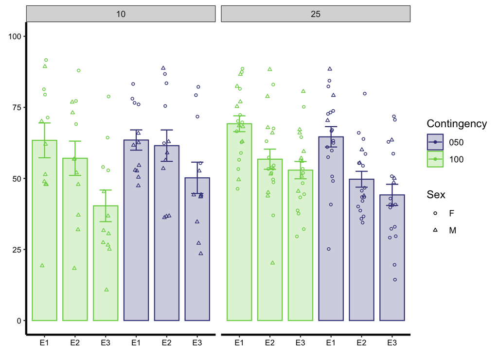

```r
Fig1.D2 <-
  ggplot(
  EXT_ave_1,
  aes(x=interaction(Exp_Type, Contingency),
      y=group_mean_freezing,
      group = Contingency,
      color = Contingency,
      fill = Contingency)) +
  scale_fill_viridis(discrete = TRUE, begin=0.2, end=0.8) +
  scale_colour_viridis(discrete = TRUE, begin=0.2, end=0.8) +
  facet_wrap(~CS_dur) +
  geom_bar(stat = "identity", alpha=0.25, width = 0.8) +
  geom_errorbar(aes(ymin = group_mean_freezing-se, ymax = group_mean_freezing+se), width=0.4) +
  geom_point(
    data=EXT_id_1,
    aes(x=interaction(Exp_Type, Contingency), y=mean_freezing, shape=Sex),
    position = position_jitterdodge(jitter.height=0, jitter.width=0.25,
                                    dodge.width = 0.8),
    size=1) +
    scale_shape(solid = FALSE) +
  scale_x_discrete(limits=c("E1.100", "E2.100", "E3.100",
                            "E1.050", "E2.050", "E3.050"),
                   labels=c("E1", "E2", "E3", "E1", "E2", "E3")) +
  ylim(0,100) +
  labs(
    x = "CS Time",
    y = "% Time Freezing") +
  theme_bw() +
  theme(

        panel.border= element_blank(),
        plot.background = element_blank(),
        plot.title = element_text(size = 18,face="bold.italic", hjust=0.5),
        panel.grid.major = element_blank(),
        panel.grid.minor = element_blank(),
        axis.text.x = element_text(size = 8, color="black"),
        axis.text.y = element_text(size = 8, color="black"),
        axis.title.x = element_text(size = 0, face= "bold"),
        axis.title.y = element_text(size = 0, face="bold"),
        axis.line.x = element_line(color="black", linewidth = 1),
        axis.line.y = element_line(color="black", linewidth = 1))

Fig1.D2
```

```r
# ggsave("Fig1D2.pdf", plot = Fig1.D2, width = 3, height = 1.5, units = "in")
```

### D2 - Stats

```r
m1.d2.FE <- EXT_id_1 %>%
  aov_ez(id = "id",
         dv = "mean_freezing",
         between = c("Contingency", "CS_dur"),
         within = c("Exp_Type"),
         data = .)
```

```
## Converting to factor: Contingency, CS_dur
```

```
## Contrasts set to contr.sum for the following variables: Contingency, CS_dur
```

```r
#ANOVA table
nice_m1.d2.FE <-nice(m1.d2.FE)
kable(nice_m1.d2.FE, caption = '<b>Figure 1.D2: Main FX</b>') %>%
  kable_styling(bootstrap_options = "striped", full_width = F, position = "left")
```

**Figure 1.D2: Main FX**

| Effect | df | MSE | F | ges | p.value |
| --- | --- | --- | --- | --- | --- |
| Contingency | 1, 59 | 567.55 | 0.08 | <.001 | .782 |
| CS_dur | 1, 59 | 567.55 | 0.00 | <.001 | .949 |
| Contingency:CS_dur | 1, 59 | 567.55 | 2.64 | .031 | .110 |
| Exp_Type | 1.77, 104.44 | 125.49 | 44.66 *** | .176 | <.001 |
| Contingency:Exp_Type | 1.77, 104.44 | 125.49 | 0.27 | .001 | .733 |
| CS_dur:Exp_Type | 1.77, 104.44 | 125.49 | 3.99 * | .019 | .026 |
| Contingency:CS_dur:Exp_Type | 1.77, 104.44 | 125.49 | 1.61 | .008 | .208 |

```r
#Post-hoc analyses
n1.d2 <- emmeans(m1.d2.FE, ~ Exp_Type * CS_dur)

#Simple contrasts for Extinction Day
n1.d2_pairs <- pairs(n1.d2, simple="each")
kable(n1.d2_pairs[], caption = '<b>Figure 1.D2-E1:Simple Contrasts for FE Day and CS Dur</b>')
```

**Figure 1.D2-E1:Simple Contrasts for FE Day and CS Dur**

| contrast | CS_dur | estimate | SE | df | t.ratio | p.value |
| --- | --- | --- | --- | --- | --- | --- |
| E1 - E2 | 10 | 4.140347 | 3.409290 | 59 | 1.214431 | 0.4494707 |
| E1 - E3 | 10 | 18.168958 | 3.178910 | 59 | 5.715469 | 0.0000011 |
| E2 - E3 | 10 | 14.028611 | 2.457143 | 59 | 5.709317 | 0.0000012 |
| E1 - E2 | 25 | 13.700866 | 2.675346 | 59 | 5.121156 | 0.0000104 |
| E1 - E3 | 25 | 18.375269 | 2.494562 | 59 | 7.366130 | 0.0000000 |
| E2 - E3 | 25 | 4.674402 | 1.928176 | 59 | 2.424261 | 0.0476969 |

| contrast | Exp_Type | estimate | SE | df | t.ratio | p.value |
| --- | --- | --- | --- | --- | --- | --- |
| CS_dur10 - CS_dur25 | E1 | -3.486148 | 3.996342 | 59 | -0.8723346 | 0.3865622 |
| CS_dur10 - CS_dur25 | E2 | 6.074371 | 4.306630 | 59 | 1.4104697 | 0.1636518 |
| CS_dur10 - CS_dur25 | E3 | -3.279837 | 4.318216 | 59 | -0.7595352 | 0.4505566 |

## F. Extinction Recall

Extinction recall was measured at recent (48 h) or remote (30 d) timepoints. Mice were returned to Context B and received a tone test (4 CS presentations) 48 hours and 30 days after the last day of extinction training. In addition to comparing experimental groups at each time point, we also compared percent time freezing within-subjects between the recent and remote time points to assess the level of spontaneous recovery, or the return of conditioned fear with the passage of time

Note: in the data we called the 48h tone test “ER” and the 30d tone-test “SR”

### F - Dataframe

```r
ER_id_1 <- df %>%
  filter(str_detect(Component.Name, "pre-tone|post-tone", negate = TRUE),
         str_detect(Trials, "3"),
         str_detect(Exp_Type, "ER")) %>%
  group_by(id, Sex, CS_dur, Contingency, Exp_Type) %>%
  summarize(mean_freezing=mean(Pct.Component.Time.Freezing), n=n(),
            se=sd(Pct.Component.Time.Freezing/sqrt(n())))
```

```
## can override using the `.groups` argument.
```

```r
ER_ave_1 <- ER_id_1 %>%
  group_by(CS_dur, Contingency, Exp_Type) %>%
  summarize(group_mean_freezing=mean(mean_freezing), n=n(),
            se=sd(mean_freezing/sqrt(n())))
SR_id_1 <- df %>%
  filter(str_detect(Component.Name, "pre-tone|post-tone", negate = TRUE),
         str_detect(Trials, "3"),
         str_detect(Exp_Type, "SR")) %>%
  group_by(id, Sex, CS_dur, Contingency, Exp_Type) %>%
  summarize(mean_freezing=mean(Pct.Component.Time.Freezing), n=n(),
            se=sd(Pct.Component.Time.Freezing/sqrt(n())))
```

```
## can override using the `.groups` argument.
```

```r
SR_ave_1 <- SR_id_1 %>%
  group_by(CS_dur, Contingency, Exp_Type) %>%
  summarize(group_mean_freezing=mean(mean_freezing), n=n(),
            se=sd(mean_freezing/sqrt(n())))
ER_SR_id_1 <-rbind(ER_id_1, SR_id_1)
ER_SR_ave_1 <-rbind(ER_ave_1, SR_ave_1)
```

### F - Graph

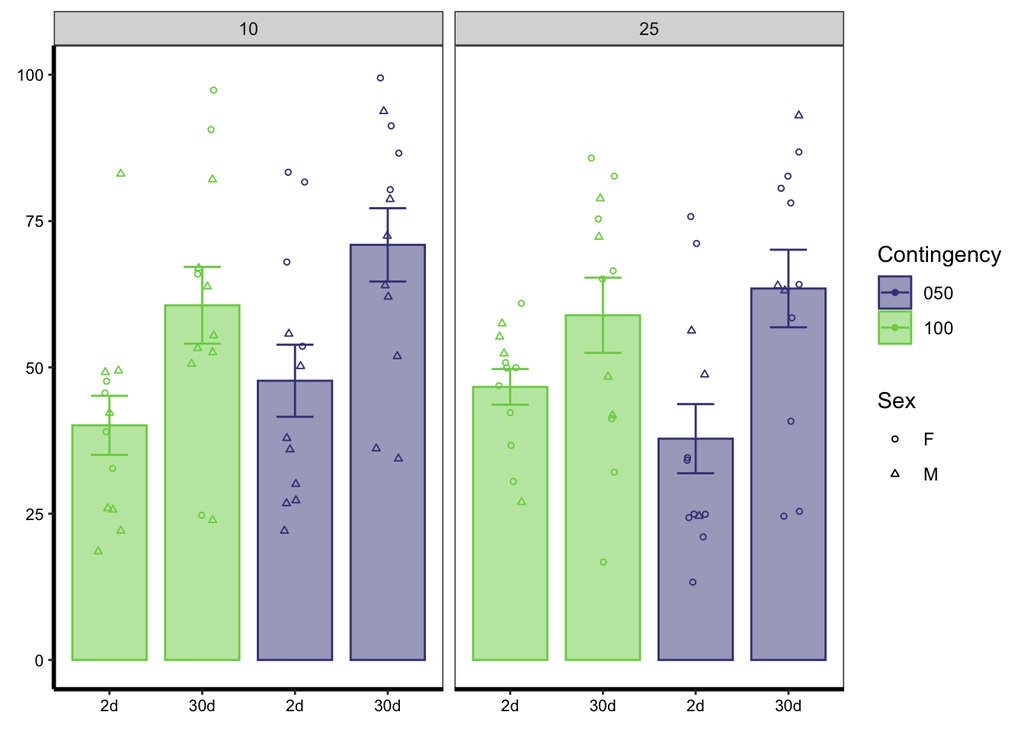

```r
Fig1F <-
  ggplot(
  ER_SR_ave_1,
  aes(x=interaction(Exp_Type, Contingency),
      y=group_mean_freezing,
      group = Contingency,
      color = Contingency,
      fill = Contingency)) +
  scale_fill_viridis(discrete = TRUE, begin=0.2, end=0.8) +
  scale_colour_viridis(discrete = TRUE, begin=0.2, end=0.8) +
  facet_wrap(~CS_dur) +
  geom_bar(stat = "identity", alpha=0.5, width = 0.8) +
  geom_errorbar(aes(ymin = group_mean_freezing-se, ymax = group_mean_freezing+se), width=0.4) +
  geom_point(
    data=ER_SR_id_1,
    aes(x=interaction(Exp_Type, Contingency), y=mean_freezing, shape=Sex),
    position = position_jitterdodge(jitter.height=0, jitter.width=0.25,
                                    dodge.width = 0.8),
    size=1 ) +
  scale_shape(solid = FALSE) +
  scale_x_discrete(limits= c("ER.100", "SR.100", "ER.050", "SR.050"),
                  labels= c("2d", "30d", "2d", "30d")) +
  ylim(0,100) +
  labs(x = "Day", y = "% Time Freezing") +
  theme_bw() +
  theme(

        plot.background = element_blank(),
        plot.title = element_text(size = 18,face="bold.italic", hjust=0.5),
        panel.grid.major = element_blank(),
        panel.grid.minor = element_blank(),
        axis.text.x = element_text(size = 8, color="black"),
        axis.text.y = element_text(size = 8, color="black"),
        axis.title.x = element_text(size = 0, face= "bold"),
        axis.title.y = element_text(size = 0, face="bold"),
        axis.line.x = element_line(color="black", linewidth = 1),
        axis.line.y = element_line(color="black", linewidth = 1)) +
  labs(
    x = "CS Time",
    y = "% Time Freezing")

Fig1F
```

```r
#ggsave("Fig1F.pdf", plot = Fig1F, width = 3, height = 1.5, units = "in")
```

### F - Stats

```r
m1f <- ER_SR_id_1 %>%
  aov_ez(id = "id",
         dv = "mean_freezing",
         between = c("Contingency", "CS_dur"),
         within = "Exp_Type",
         data = .)
```

```
## Converting to factor: Contingency, CS_dur
```

```
## Contrasts set to contr.sum for the following variables: Contingency, CS_dur
```

```r
nice_m1f <- nice(m1f)

#ANOVA table
kable(nice_m1f, caption = '<b>Figure 1F Main FX</b>') %>%
  kable_styling(bootstrap_options = "striped", full_width = F, position = "left")
```

**Figure 1F Main FX**

| Effect | df | MSE | F | ges | p.value |
| --- | --- | --- | --- | --- | --- |
| Contingency | 1, 44 | 566.16 | 0.50 | .008 | .485 |
| CS_dur | 1, 44 | 566.16 | 0.41 | .006 | .523 |
| Contingency:CS_dur | 1, 44 | 566.16 | 1.31 | .020 | .259 |
| Exp_Type | 1, 44 | 258.83 | 38.62 *** | .216 | <.001 |
| Contingency:Exp_Type | 1, 44 | 258.83 | 1.51 | .011 | .226 |
| CS_dur:Exp_Type | 1, 44 | 258.83 | 0.20 | .001 | .659 |
| Contingency:CS_dur:Exp_Type | 1, 44 | 258.83 | 0.67 | .005 | .419 |

```r
#Post-hoc analyses
n1f <- emmeans(m1f, ~Exp_Type)
n1f_ExpType <- pairs(n1f, simple = "Exp_Type")

#Simple contrasts for ExpType
kable(n1f_ExpType, caption = '<b>Figure 1F: Simple Contrast for Tone-test day')
```

**Figure 1F: Simple Contrast for Tone-test day**

| contrast | estimate | SE | df | t.ratio | p.value |
| --- | --- | --- | --- | --- | --- |
| ER - SR | -20.40797 | 3.283988 | 44 | -6.214386 | 2e-07 |

## END of Fig 1

# Fig 2. No effect of partial reinforcement on fear extinction acquisition or consolidation with increased CS:US trials during fear conditioning:

## B. Fear Acquisition

Compare the average percent time freezing during CS presentations across the two days of FC training

## B1 - Within-session FC

### B1 - Dataframe

```r
#Create a dataframe with averages for each animal for each CS
FC_id_2.1 <- df %>%
  filter(
         str_detect(Exp_Type, "FC"),
         str_detect(CS_dur, "10"),
         str_detect(Trials, "6")) %>%
  group_by(id, Contingency, Sex, Component.Name, Exp_Type, CS) %>%
  summarize(mean_freezing=mean(Pct.Component.Time.Freezing), n=n(),
            se=sd(Pct.Component.Time.Freezing/sqrt(n())))
```

```
## 'Component.Name', 'Exp_Type'. You can override using the `.groups` argument.
```

```r
#Create a dataframe with averages for each experimental group for each CS
FC_ave_2.1 <- FC_id_2.1 %>%
  group_by(Contingency, Component.Name, Exp_Type) %>%
  summarize(group_mean_freezing=mean(mean_freezing), n=n(),
            se=sd(mean_freezing/sqrt(n())))
```

### B1 - Graph

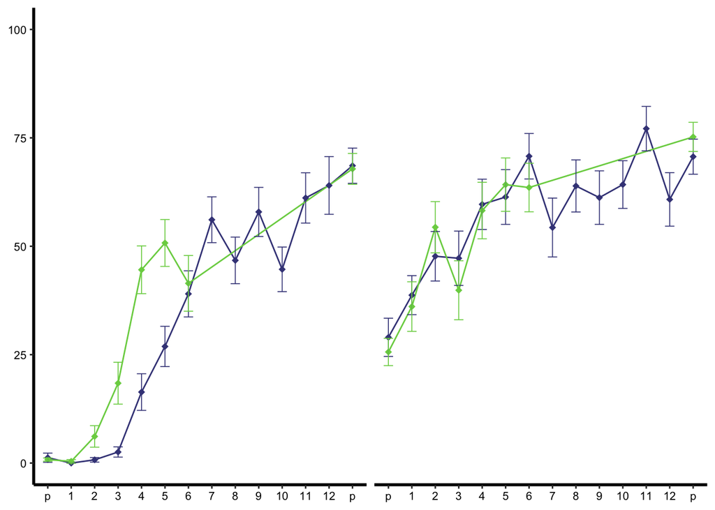

```r
Fig2B.1 <-
  ggplot(FC_ave_2.1, aes(x=interaction(Component.Name), y=group_mean_freezing, group=Contingency, color=Contingency)) +
  scale_fill_viridis(discrete = TRUE, begin=0.2, end=0.8) +
  scale_colour_viridis(discrete = TRUE, begin=0.2, end=0.8) +
  facet_wrap(~Exp_Type) +
  geom_line() +
  geom_point(shape=18, size=2) +
  geom_errorbar(aes(ymin = group_mean_freezing-se, ymax = group_mean_freezing+se, width = 0.4), linewidth=0.3) +
  ylim(0,100) +
  scale_x_discrete(limits=c("pre-tone", "tone 01", "tone 02", "tone 03",  "tone 04", "tone 05", "tone 06", "tone 07", "tone 08", "tone 09", "tone 10", "tone 11", "tone 12", "post-tone"),
                   labels=c("p", "1", "2", "3", "4", "5", "6", "7", "8", "9", "10", "11", "12", "p")) +
  labs(
    x = "CS Time",
    y = "% Time Freezing") +
  theme_bw() +
  theme(legend.position = "none",
        panel.border = element_blank(),
        strip.text = element_blank(),
        strip.background = element_blank(),
        plot.background = element_blank(),
        plot.title = element_blank(),
        panel.grid.major = element_blank(),
        panel.grid.minor = element_blank(),
        axis.text.x = element_text(size = 8, color="black"),
        axis.text.y = element_text(size = 8, color="black"),
        axis.title.x = element_blank(),
        axis.title.y = element_blank(),
        axis.line.x = element_line(color="black", linewidth = 1),
        axis.line.y = element_line(color="black", linewidth = 1))

Fig2B.1
```

```r
#ggsave("Fig2B-1.pdf", plot = Fig2B.1, width = 2.5, height = 2, units = "in")
```

### B1 - Stats

```r
# ANOVA model 1 (Fig1B-1) - uses only CS paired with US (i.e. 3 total, CS 1-3 for 100% Contingency, and CS1,3,6 for 50% Contingency)

# Analysis of FC1 Data
m2b1_FC1 <- FC_id_2.1 %>%
   filter(str_detect(CS, "tone 01|tone 02|tone 03|tone 04|tone 05|tone 06") &
          Exp_Type == "FC1") %>%
  aov_ez(id = "id",
         dv = "mean_freezing",
         between = c("Contingency"),
         within = c("CS"),
         data = .)
```

```
## Converting to factor: Contingency
```

```
## Contrasts set to contr.sum for the following variables: Contingency
```

```r
#ANOVA table
nice_m2b1_FC1 <-nice(m2b1_FC1)
kable(nice_m2b1_FC1, caption = '<b>Figure 2-B1: Main FX for FC1</b>') %>%
  kable_styling(bootstrap_options = "striped", full_width = F, position = "left")
```

**Figure 2-B1: Main FX for FC1**

| Effect | df | MSE | F | ges | p.value |
| --- | --- | --- | --- | --- | --- |
| Contingency | 1, 60 | 1380.14 | 11.17 ** | .057 | .001 |
| CS | 3.91, 234.31 | 725.55 | 54.46 *** | .379 | <.001 |
| Contingency:CS | 3.91, 234.31 | 725.55 | 5.32 *** | .056 | <.001 |

```r
#Post-hoc analyses

#Contrast for Contingency x CS interaction
n2b1.1_FC1 <- emmeans(m2b1_FC1, ~ Contingency*CS)
n2b1.1_pairs_FC1<- pairs(n2b1.1_FC1, simple="each")

kable(n2b1.1_pairs_FC1[1], caption = '<b>Figure 1B-1: Simple contrasts ny Contingency</b>')
```

**Figure 1B-1: Simple contrasts ny Contingency**

| contrast | CS | estimate | SE | df | t.ratio | p.value |
| --- | --- | --- | --- | --- | --- | --- |
| Contingency050 - Contingency100 | tone.01 | 0.350000 | 0.6652902 | 60 | 0.5260862 | 0.6007676 |
| Contingency050 - Contingency100 | tone.02 | 10.231000 | 4.9813432 | 60 | 2.0538637 | 0.0443540 |
| Contingency050 - Contingency100 | tone.03 | 37.692687 | 7.1823200 | 60 | 5.2479822 | 0.0000021 |
| Contingency050 - Contingency100 | tone.04 | 2.161083 | 7.6924484 | 60 | 0.2809357 | 0.7797262 |
| Contingency050 - Contingency100 | tone.05 | 7.161208 | 7.8514070 | 60 | 0.9120924 | 0.3653704 |
| Contingency050 - Contingency100 | tone.06 | 19.701563 | 8.6294159 | 60 | 2.2830702 | 0.0259834 |

```r
kable(n2b1.1_pairs_FC1[2], caption = '<b>Figure 1B-1: Simple contrasts by CS Day</b>')
```

**Figure 1B-1: Simple contrasts by CS Day**

| contrast | Contingency | estimate | SE | df | t.ratio | p.value |
| --- | --- | --- | --- | --- | --- | --- |
| tone.01 - tone.02 | 050 | -15.625000 | 3.371458 | 60 | -4.6344936 | 0.0002760 |
| tone.01 - tone.03 | 050 | -55.364688 | 4.838044 | 60 | -11.4436090 | 0.0000000 |
| tone.01 - tone.04 | 050 | -45.988750 | 5.281689 | 60 | -8.7072052 | 0.0000000 |
| tone.01 - tone.05 | 050 | -57.166875 | 5.371481 | 60 | -10.6426645 | 0.0000000 |
| tone.01 - tone.06 | 050 | -60.396563 | 5.981079 | 60 | -10.0979373 | 0.0000000 |
| tone.02 - tone.03 | 050 | -39.739688 | 5.104713 | 60 | -7.7849012 | 0.0000000 |
| tone.02 - tone.04 | 050 | -30.363750 | 4.984770 | 60 | -6.0913039 | 0.0000013 |
| tone.02 - tone.05 | 050 | -41.541875 | 5.507919 | 60 | -7.5422084 | 0.0000000 |
| tone.02 - tone.06 | 050 | -44.771563 | 5.782897 | 60 | -7.7420649 | 0.0000000 |
| tone.03 - tone.04 | 050 | 9.375937 | 6.364029 | 60 | 1.4732708 | 0.6822740 |
| tone.03 - tone.05 | 050 | -1.802188 | 6.637954 | 60 | -0.2714974 | 0.9997899 |
| tone.03 - tone.06 | 050 | -5.031875 | 6.380450 | 60 | -0.7886395 | 0.9684249 |
| tone.04 - tone.05 | 050 | -11.178125 | 6.923042 | 60 | -1.6146261 | 0.5923377 |
| tone.04 - tone.06 | 050 | -14.407813 | 7.312723 | 60 | -1.9702390 | 0.3712656 |
| tone.05 - tone.06 | 050 | -3.229687 | 7.912810 | 60 | -0.4081593 | 0.9984735 |
| tone.01 - tone.02 | 100 | -5.744000 | 3.482027 | 60 | -1.6496140 | 0.5697275 |
| tone.01 - tone.03 | 100 | -18.022000 | 4.996711 | 60 | -3.6067728 | 0.0079425 |
| tone.01 - tone.04 | 100 | -44.177667 | 5.454905 | 60 | -8.0987051 | 0.0000000 |
| tone.01 - tone.05 | 100 | -50.355667 | 5.547642 | 60 | -9.0769493 | 0.0000000 |
| tone.01 - tone.06 | 100 | -41.045000 | 6.177232 | 60 | -6.6445618 | 0.0000001 |
| tone.02 - tone.03 | 100 | -12.278000 | 5.272125 | 60 | -2.3288522 | 0.1988689 |
| tone.02 - tone.04 | 100 | -38.433667 | 5.148249 | 60 | -7.4653868 | 0.0000000 |
| tone.02 - tone.05 | 100 | -44.611667 | 5.688555 | 60 | -7.8423554 | 0.0000000 |
| tone.02 - tone.06 | 100 | -35.301000 | 5.972550 | 60 | -5.9105406 | 0.0000025 |
| tone.03 - tone.04 | 100 | -26.155667 | 6.572741 | 60 | -3.9794156 | 0.0024936 |
| tone.03 - tone.05 | 100 | -32.333667 | 6.855650 | 60 | -4.7163533 | 0.0002071 |
| tone.03 - tone.06 | 100 | -23.023000 | 6.589700 | 60 | -3.4937857 | 0.0111044 |
| tone.04 - tone.05 | 100 | -6.178000 | 7.150087 | 60 | -0.8640454 | 0.9535345 |
| tone.04 - tone.06 | 100 | 3.132667 | 7.552548 | 60 | 0.4147828 | 0.9983508 |
| tone.05 - tone.06 | 100 | 9.310667 | 8.172315 | 60 | 1.1392936 | 0.8629266 |

```r
#######################
# Analysis of FC2 Data
m2b1_FC2 <- FC_id_2.1 %>%
   filter(str_detect(CS, "tone 01|tone 02|tone 03|tone 04|tone 05|tone 06") &
          Exp_Type == "FC2") %>%
  aov_ez(id = "id",
         dv = "mean_freezing",
         between = c("Contingency"),
         within = c("CS"),
         data = .)
```

```
## Converting to factor: Contingency
## Contrasts set to contr.sum for the following variables: Contingency
```

```r
#ANOVA table
nice_m2b1_FC2 <-nice(m2b1_FC2)
kable(nice_m2b1_FC2, caption = '<b>Figure 2-B1: Main FX for FC2</b>') %>%
  kable_styling(bootstrap_options = "striped", full_width = F, position = "left")
```

**Figure 2-B1: Main FX for FC2**

| Effect | df | MSE | F | ges | p.value |
| --- | --- | --- | --- | --- | --- |
| Contingency | 1, 60 | 2354.48 | 0.55 | .003 | .463 |
| CS | 4.50, 270.00 | 982.44 | 7.33 *** | .074 | <.001 |
| Contingency:CS | 4.50, 270.00 | 982.44 | 0.73 | .008 | .584 |

```r
# Post-hoc analyses

#Contrast for CS x FC Day interaction
n2b1.1_FC2 <- emmeans(m2b1_FC2, ~ CS)
n2b1.1_pairs_FC2<- pairs(n2b1.1_FC2, simple="each")

kable(n2b1.1_pairs_FC2[1], caption = '<b>Figure 1B-1: Simple contrasts for Contingency by CS</b>')
```

| contrast | estimate | SE | df | t.ratio | p.value |
| --- | --- | --- | --- | --- | --- |
| tone.01 - tone.02 | -19.6239062 | 4.534513 | 60 | -4.3276764 | 0.0007918 |
| tone.01 - tone.03 | -9.6848750 | 5.095076 | 60 | -1.9008303 | 0.4117437 |
| tone.01 - tone.04 | -23.6665417 | 4.673100 | 60 | -5.0644201 | 0.0000596 |
| tone.01 - tone.05 | -25.3111354 | 4.981798 | 60 | -5.0807228 | 0.0000561 |
| tone.01 - tone.06 | -24.7687292 | 5.512762 | 60 | -4.4929801 | 0.0004508 |
| tone.02 - tone.03 | 9.9390312 | 5.944331 | 60 | 1.6720184 | 0.5552504 |
| tone.02 - tone.04 | -4.0426354 | 5.440469 | 60 | -0.7430675 | 0.9756029 |
| tone.02 - tone.05 | -5.6872292 | 4.937337 | 60 | -1.1518819 | 0.8573840 |
| tone.02 - tone.06 | -5.1448229 | 6.130328 | 60 | -0.8392411 | 0.9588678 |
| tone.03 - tone.04 | -13.9816667 | 5.905953 | 60 | -2.3673853 | 0.1843925 |
| tone.03 - tone.05 | -15.6262604 | 5.325264 | 60 | -2.9343635 | 0.0512036 |
| tone.03 - tone.06 | -15.0838542 | 6.128773 | 60 | -2.4611541 | 0.1524213 |
| tone.04 - tone.05 | -1.6445937 | 4.439827 | 60 | -0.3704184 | 0.9990437 |
| tone.04 - tone.06 | -1.1021875 | 5.534001 | 60 | -0.1991665 | 0.9999544 |
| tone.05 - tone.06 | 0.5424062 | 5.164858 | 60 | 0.1050186 | 0.9999981 |

## B2 - Between-session FC

### B2 - Dataframe

```r
#Create a dataframe with CS freezing averaged for each experimental group
FC_id_2.2 <- FC_id_2.1 %>%
  filter(str_detect(Component.Name, "pre-tone|post-tone", negate=TRUE)) %>%
  group_by(id, Sex, Contingency, Exp_Type) %>%
  summarize(mean_freezing=mean(mean_freezing), n=n(),
            se=sd(mean_freezing/sqrt(n())))
FC_ave_2.2 <- FC_id_2.2 %>%
  group_by(Contingency, Exp_Type) %>%
  summarize(group_mean_freezing=mean(mean_freezing), n=n(),
            se=sd(mean_freezing/sqrt(n())))
```

### B2 - Graph

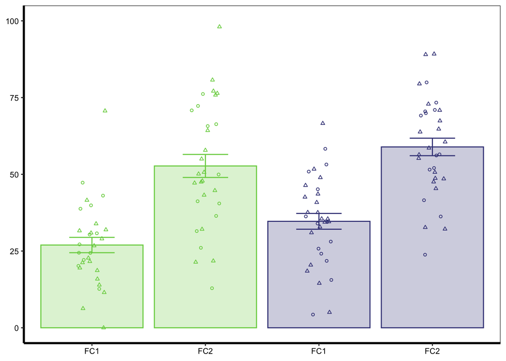

```r
Fig2B.2 <- ggplot(FC_ave_2.2,
  aes(x=interaction(Exp_Type,Contingency),
      y=group_mean_freezing,
      group = Contingency, fill= Contingency, color=Contingency)) +
  scale_color_viridis_d(begin=0.2, end=0.8) +
  scale_fill_viridis_d(begin=0.2, end=0.8) +
  geom_errorbar(aes(ymin = group_mean_freezing-se, ymax = group_mean_freezing+se), width=0.4) +
  geom_bar(stat="identity", alpha=0.25) +
  geom_point(
    data=FC_id_2.2,
    aes(x=interaction(Exp_Type, Contingency), y=mean_freezing, shape=Sex),position = position_jitterdodge(jitter.height=0, jitter.width=0.25, dodge.width = 0.8), size=1) +
  scale_shape(solid = FALSE) +
   scale_x_discrete(limits=c("FC1.100","FC2.100", "FC1.050", "FC2.050"),
                    labels= c("FC1", "FC2", "FC1", "FC2")) +
  ylim(0,100) +
  theme_bw() +
  theme(legend.position = "none",
        strip.background = element_blank(),
        strip.text = element_blank(),
        plot.background = element_blank(),
        axis.title.x = element_blank(),
        axis.title.y = element_blank(),
        plot.title = element_blank(),
        panel.grid.major = element_blank(),
        panel.grid.minor = element_blank(),
        axis.text.x = element_text(size = 8, color="black"),
        axis.text.y = element_text(size = 8, color="black"),
        axis.line.x = element_line(color="black", linewidth = 1),
        axis.line.y = element_line(color="black", linewidth = 1))+
  labs(
    x = "CS Time",
    y = "% Time Freezing")

Fig2B.2
```

```r
#ggsave("Fig2B-2.pdf", plot = Fig2B.2, width = 1, height = 2, units = "in")
```

### B2 - Stats

```r
# ANOVA model 2 (Fig1B-2) - uses all CS  (i.e. 3 total for 100% Contingency, and 6 for 50% Contingency)
m1b2 <- FC_id_2.2 %>%
  aov_ez(id = "id",
         dv = "mean_freezing",
         between = c("Contingency"),
         within = c("Exp_Type"),
         data = .)
```

```
## Converting to factor: Contingency
```

```
## Contrasts set to contr.sum for the following variables: Contingency
```

```r
#ANOVA table
nice_m1b2  <-nice(m1b2)
kable(nice_m1b2, caption = '<b>Figure 2-B2: Main FX</b>') %>%
  kable_styling(bootstrap_options = "striped", full_width = F, position = "left")
```

**Figure 2-B2: Main FX**

| Effect | df | MSE | F | ges | p.value |
| --- | --- | --- | --- | --- | --- |
| Contingency | 1, 60 | 369.71 | 4.06 * | .044 | .048 |
| Exp_Type | 1, 60 | 168.13 | 115.11 *** | .375 | <.001 |
| Contingency:Exp_Type | 1, 60 | 168.13 | 0.11 | <.001 | .744 |

```r
#Post-hoc analyses
#Contrast for Contingency
n2b2.1 <- emmeans(m1b2, ~ Contingency)
n2b2.1_pairs<- pairs(n2b2.1, simple="each")
n2b2.1
```

```
##  Contingency emmean   SE df lower.CL upper.CL
##  050           46.8 2.40 60     42.0     51.6
##  100           39.8 2.48 60     34.9     44.8
##
## Results are averaged over the levels of: Exp_Type
## Confidence level used: 0.95
```

```r
kable(n2b2.1_pairs[1], caption = '<b>Figure 2B-2: Simple contrasts for Contingency</b>')
```

**Figure 2B-2: Simple contrasts for Contingency**

| contrast | estimate | SE | df | t.ratio | p.value |
| --- | --- | --- | --- | --- | --- |
| Contingency050 - Contingency100 | 6.962858 | 3.455236 | 60 | 2.015161 | 0.0483745 |

```r
#Contrast for FE Day
n2b2.2 <- emmeans(m1b2, ~ Exp_Type)
n2b2.2_pairs<- pairs(n2b2.2, simple="each")

kable(n2b2.2_pairs[1], caption = '<b>Figure 2B21: Simple contrasts for FC Day</b>')
```

**Figure 2B21: Simple contrasts for FC Day**

| contrast | estimate | SE | df | t.ratio | p.value |
| --- | --- | --- | --- | --- | --- |
| FC1 - FC2 | -24.99908 | 2.330084 | 60 | -10.72883 | 0 |

```r
n2b2.2
```

```
##  Exp_Type emmean   SE df lower.CL upper.CL
##  FC1        30.8 1.80 60     27.2     34.4
##  FC2        55.8 2.34 60     51.1     60.5
##
## Results are averaged over the levels of: Contingency
## Confidence level used: 0.95
```

## C. Fear Retrieval ———————————————————-

Retrieval was evaluated as the proportion of time freezing between two CS epochs: (1) CS freezing on FC Day 2 and (2) the first four CS presentations on Extinction Day 1.

### C - Dataframe

```r
E1_Session1_id_2 <- df %>%
  filter(str_detect(Exp_Type, "E1"),
         str_detect(Exp_Type, "ER", negate = TRUE),
         str_detect(CS_dur, "10"),
         str_detect(Trials, "6"),
         str_detect(Component.Name,  "tone 01|tone 02|tone 03|tone 04")) %>%
  group_by(id, Contingency, Exp_Type, Sex) %>%
  summarize(mean_freezing=mean(Pct.Component.Time.Freezing), n=n(),
            se=sd(Pct.Component.Time.Freezing/sqrt(n())))
E1_Session1_ave_2 <- E1_Session1_id_2 %>%
  group_by(Contingency, Exp_Type) %>%
  summarize(group_mean_freezing=mean(mean_freezing), n=n(),
            se=sd(mean_freezing/sqrt(n())))
FC2_id_2 <- df %>%
  filter(str_detect(Component.Name, "pre-tone|post-tone", negate = TRUE),
         str_detect(Exp_Type, "FC2"),
         str_detect(CS_dur, "10"),
         str_detect(Trials, "6")) %>%
  group_by(id, Contingency, Exp_Type, Sex) %>%
  summarize(mean_freezing=mean(Pct.Component.Time.Freezing), n=n(),
            se=sd(Pct.Component.Time.Freezing/sqrt(n())))
FC2_ave_2 <- FC2_id_2 %>%
  group_by(Contingency, Exp_Type) %>%
  summarize(group_mean_freezing=mean(mean_freezing), n=n(),
            se=sd(mean_freezing/sqrt(n())))
E1_FC2_ave_2 <-rbind(E1_Session1_ave_2, FC2_ave_2)

E1_FC2_id_2 <-rbind(E1_Session1_id_2, FC2_id_2)
E1_FC2_id_2 <- E1_FC2_id_2
```

### C - Graph

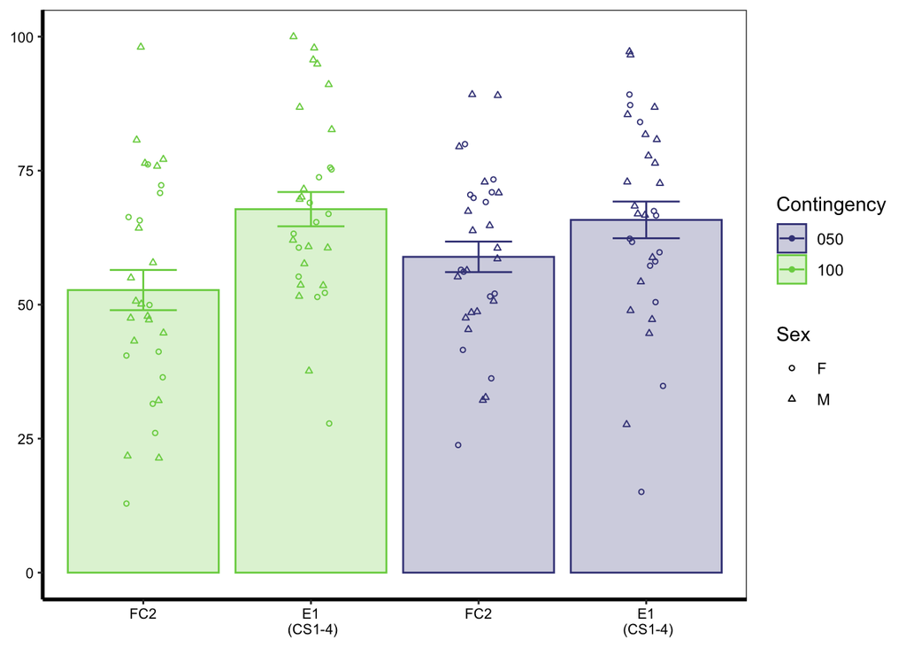

```r
Fig2C <- ggplot(
  E1_FC2_ave_2,
  aes(x=interaction(Exp_Type,Contingency),
      y=group_mean_freezing,
      group = Contingency, fill= Contingency, color=Contingency)) +
  scale_fill_viridis(discrete = TRUE, begin=0.2, end=0.8) +
  scale_colour_viridis(discrete = TRUE, begin=0.2, end=0.8) +
  geom_errorbar(aes(ymin = group_mean_freezing-se, ymax = group_mean_freezing+se), width=0.4) +
  geom_bar(stat="identity", alpha=0.25) +
  geom_point(
    data=E1_FC2_id_2,
    aes(x=interaction(Exp_Type, Contingency), y=mean_freezing, shape=Sex),position = position_jitterdodge(jitter.height=0, jitter.width=0.25, dodge.width = 0.8), size=1) +
  scale_shape(solid = FALSE) +
   scale_x_discrete(limits=c("FC2.100", "E1.100", "FC2.050", "E1.050"),
                    labels= c("FC2", "E1\n (CS1-4)", "FC2", "E1\n (CS1-4)")) +
  ylim(0,100) +
  theme_bw() +
  labs(
    x = "CS Time",
    y = "% Time Freezing") +
    theme(
        plot.background = element_blank(),
        plot.title = element_blank(),
        panel.grid.major = element_blank(),
        panel.grid.minor = element_blank(),
        axis.text.x = element_text(size = 8, color="black"),
        axis.text.y = element_text(size = 8, color="black"),
        axis.title.x = element_blank(),
        axis.title.y = element_blank(),
        axis.line.x = element_line(color="black", linewidth = 1),
        axis.line.y = element_line(color="black", linewidth = 1))

Fig2C
```

```r
#ggsave("Fig2C.pdf", plot = Fig2C, width = 1.5, height = 2, units = "in")
```

### C - Stats

```r
m2c <- E1_FC2_id_2 %>%
  aov_ez(id = "id",
         dv = "mean_freezing",
         between = "Contingency",
         within = "Exp_Type",
         data = .)
```

```
## Converting to factor: Contingency
```

```
## Contrasts set to contr.sum for the following variables: Contingency
```

```r
#ANOVA table
nice_m2c <- nice(m2c)

kable(nice_m2c, caption = '<b>Figure 2C: Main FX</b>') %>%
  kable_styling(bootstrap_options = "striped", full_width = F, position = "left")
```

**Figure 2C: Main FX**

| Effect | df | MSE | F | ges | p.value |
| --- | --- | --- | --- | --- | --- |
| Contingency | 1, 60 | 398.82 | 0.34 | .003 | .561 |
| Exp_Type | 1, 60 | 281.47 | 13.29 *** | .084 | <.001 |
| Contingency:Exp_Type | 1, 60 | 281.47 | 1.85 | .013 | .179 |

## D. Extinction acquisition———————————————–

### D1 - Within-session FE

To evaluate the effect of partial reinforcement on fear extinction acquisition, mice were exposed to 12 unreinforced CS presentations for three consecutive days (E1, E2, E3) in a novel context (Context B). Percent time freezing was averaged in bins composed of 3CS presentations.

### D1 - Dataframe

```r
EXT_bin_id_2 <- df %>%
  filter(str_detect(Experiment, "E"),
         str_detect(CS_dur, "10"),
         str_detect(Trials, "6"),
         str_detect(Experiment, "ER", negate = TRUE)) %>%
  group_by(Exp_Type, id, Contingency, Bin, Sex) %>%
  summarize(mean_freezing=mean(Pct.Component.Time.Freezing), n=n(),
            se=sd(Pct.Component.Time.Freezing/sqrt(n())))
```

```
## can override using the `.groups` argument.
```

```r
EXT_bin_ave_2 <- EXT_bin_id_2 %>%
  group_by(Exp_Type, Bin, Contingency) %>%
  summarize(group_mean_freezing=mean(mean_freezing), n=n(),
            se=sd(mean_freezing/sqrt(n())))
EXT_bin_ave_2$Bin <- factor(EXT_bin_ave_2$Bin, levels = c("Pre", "1", "2", "3", "4", "Post"))
```

### D1 - Graph

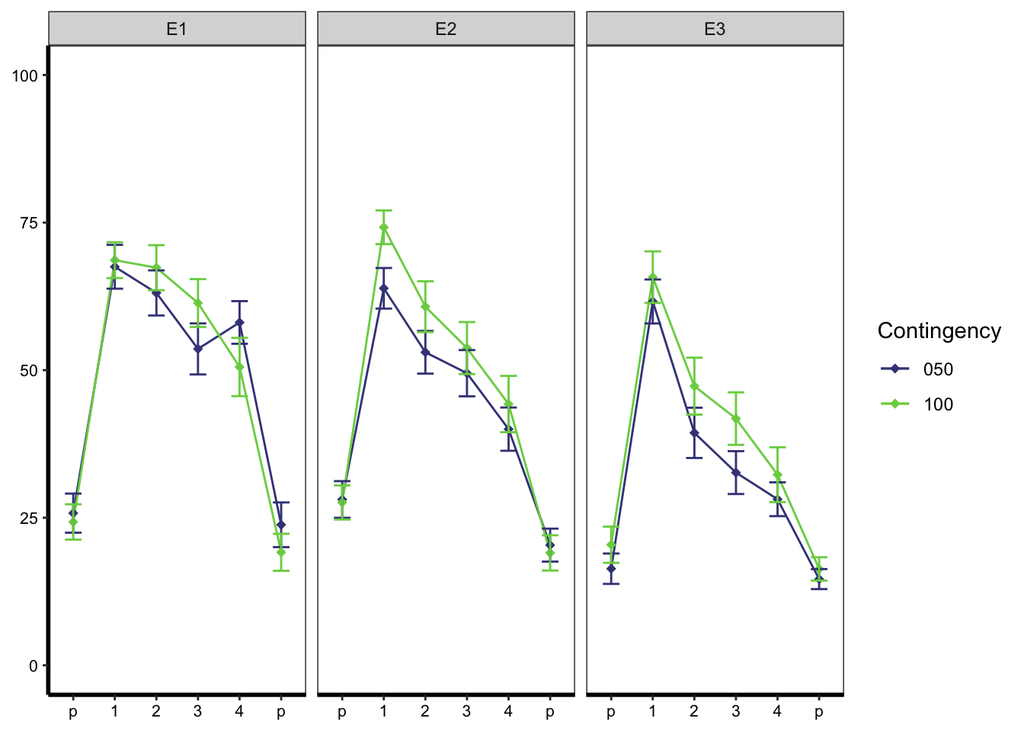

```r
Fig2D.1 <-
  ggplot(
  data = subset(EXT_bin_ave_2, !is.na(Bin)),
  aes(x=interaction(Bin),
      y=group_mean_freezing,
      group = Contingency, color= Contingency, fill=Contingency)) +
  scale_fill_viridis(discrete = TRUE, begin=0.2, end=0.8) +
  scale_colour_viridis(discrete = TRUE, begin=0.2, end=0.8) +
  facet_wrap(~Exp_Type) +
  geom_line() +
  geom_point(shape=18, size=2) +
  scale_shape(solid = FALSE) +
  geom_errorbar(aes(ymin = group_mean_freezing-se, ymax = group_mean_freezing+se), width=0.4) +
  scale_x_discrete(limits=c("Pre", "1", "2", "3", "4", "Post"),
                   labels=c("p", "1", "2", "3", "4", "p")) +
  ylim(0,100) +
  labs(x = "Bin", y = "% Time Freezing") +
  theme_bw() +
   theme(
        plot.background = element_blank(),
        plot.title = element_blank(),
        panel.grid.major = element_blank(),
        panel.grid.minor = element_blank(),
        axis.text.x = element_text(size = 8, color="black"),
        axis.text.y = element_text(size = 8, color="black"),
        axis.title.x = element_blank(),
        axis.title.y = element_blank(),
        axis.line.x = element_line(color="black", linewidth = 1),
        axis.line.y = element_line(color="black", linewidth = 1))

Fig2D.1
```

```r
#ggsave("Fig2D1.pdf", plot = Fig2D.1, width = 2, height = 2, units = "in")
```

### D1 - Stats

```r
######## E1
m2d1.E1 <- EXT_bin_id_2 %>%
  filter(str_detect(Bin, "Pre|Post", negate = TRUE)) %>%
  filter(Exp_Type == "E1") %>%
  aov_ez(id = "id",
         dv = "mean_freezing",
         between = "Contingency",
         within = c("Bin"),
         data = .)
```

```
## Converting to factor: Contingency
```

```
## Contrasts set to contr.sum for the following variables: Contingency
```

```r
nice_m2d1.E1 <- nice(m2d1.E1)

kable(nice_m2d1.E1, caption = '<b>Figure 2-D1: E1 Main FX</b>') %>%
  kable_styling(bootstrap_options = "striped", full_width = F, position = "left")
```

**Figure 2-D1: E1 Main FX**

| Effect | df | MSE | F | ges | p.value |
| --- | --- | --- | --- | --- | --- |
| Contingency | 1, 60 | 1368.85 | 0.09 | .001 | .766 |
| Bin | 2.77, 166.14 | 202.54 | 13.77 *** | .063 | <.001 |
| Contingency:Bin | 2.77, 166.14 | 202.54 | 3.56 * | .017 | .018 |

```r
#Post-hoc analyses
n2d1.E1 <- emmeans(m2d1.E1, ~ Contingency * Bin)

#Simple contrasts for Contingency X Bin
pairs_n2d1.E1 <- pairs(n2d1.E1, simple="each")

# By Contingency (no sig effects)
 kable(pairs_n2d1.E1[1], caption = '<b>Figure 2D: Simple Contrasts for Contingency by bin</b>')
```

**Figure 2D: Simple Contrasts for Contingency by bin**

| contrast | Bin | estimate | SE | df | t.ratio | p.value |
| --- | --- | --- | --- | --- | --- | --- |
| Contingency050 - Contingency100 | X1 | -1.122875 | 4.828636 | 60 | -0.2325450 | 0.8169062 |
| Contingency050 - Contingency100 | X2 | -4.276382 | 5.403644 | 60 | -0.7913886 | 0.4318347 |
| Contingency050 - Contingency100 | X3 | -7.776764 | 5.945792 | 60 | -1.3079441 | 0.1958814 |
| Contingency050 - Contingency100 | X4 | 7.545604 | 6.062833 | 60 | 1.2445675 | 0.2181304 |

```r
# By Bin
kable(pairs_n2d1.E1[2], caption = '<b>Figure 2D: E1 Simple Contrasts for Bin by Contingency</b>')
```

**Figure 2D: E1 Simple Contrasts for Bin by Contingency**

| contrast | Contingency | estimate | SE | df | t.ratio | p.value |
| --- | --- | --- | --- | --- | --- | --- |
| X1 - X2 | 050 | 4.430729 | 3.268780 | 60 | 1.3554689 | 0.5318792 |
| X1 - X3 | 050 | 13.915000 | 3.301623 | 60 | 4.2145936 | 0.0004856 |
| X1 - X4 | 050 | 9.430521 | 3.635598 | 60 | 2.5939392 | 0.0562115 |
| X2 - X3 | 050 | 9.484271 | 3.268482 | 60 | 2.9017360 | 0.0259500 |
| X2 - X4 | 050 | 4.999792 | 3.916440 | 60 | 1.2766166 | 0.5812175 |
| X3 - X4 | 050 | -4.484479 | 3.046239 | 60 | -1.4721365 | 0.4604771 |
| X1 - X2 | 100 | 1.277222 | 3.375981 | 60 | 0.3783262 | 0.9813803 |
| X1 - X3 | 100 | 7.261111 | 3.409902 | 60 | 2.1294194 | 0.1555838 |
| X1 - X4 | 100 | 18.099000 | 3.754830 | 60 | 4.8201919 | 0.0000590 |
| X2 - X3 | 100 | 5.983889 | 3.375673 | 60 | 1.7726505 | 0.2964598 |
| X2 - X4 | 100 | 16.821778 | 4.044881 | 60 | 4.1587815 | 0.0005856 |
| X3 - X4 | 100 | 10.837889 | 3.146142 | 60 | 3.4448190 | 0.0056371 |

```r
######## E2
m2d1.E2 <- EXT_bin_id_2 %>%
  filter(str_detect(Bin, "Pre|Post", negate = TRUE)) %>%
  filter(Exp_Type == "E2") %>%
  aov_ez(id = "id",
         dv = "mean_freezing",
         between = "Contingency",
         within = c("Bin"),
         data = .)
```

```
## Converting to factor: Contingency
## Contrasts set to contr.sum for the following variables: Contingency
```

```r
nice_m2d1.E2 <- nice(m2d1.E2)

kable(nice_m2d1.E2, caption = '<b>Figure 2-D1: E2 Main FX</b>') %>%
  kable_styling(bootstrap_options = "striped", full_width = F, position = "left")
```

**Figure 2-D1: E2 Main FX**

| Effect | df | MSE | F | ges | p.value |
| --- | --- | --- | --- | --- | --- |
| Contingency | 1, 60 | 1433.10 | 1.91 | .024 | .172 |
| Bin | 2.59, 155.21 | 175.20 | 51.59 *** | .171 | <.001 |
| Contingency:Bin | 2.59, 155.21 | 175.20 | 0.90 | .004 | .432 |

```r
#Post-hoc analyses
n2d1.E2 <- emmeans(m2d1.E2, ~ Bin)

#Simple contrasts for Contingency X Bin
pairs_n2d1.E2 <- pairs(n2d1.E2, simple="each")

# By Bin
kable(pairs_n2d1.E2[1], caption = '<b>Figure 2D: E2 Simple Contrasts for Bin</b>')
```

**Figure 2D: E2 Simple Contrasts for Bin**

| contrast | estimate | SE | df | t.ratio | p.value |
| --- | --- | --- | --- | --- | --- |
| X1 - X2 | 12.145392 | 2.024951 | 60 | 5.997869 | 0.0000007 |
| X1 - X3 | 17.422042 | 2.181820 | 60 | 7.985096 | 0.0000000 |
| X1 - X4 | 26.900309 | 2.739173 | 60 | 9.820596 | 0.0000000 |
| X2 - X3 | 5.276649 | 1.920411 | 60 | 2.747667 | 0.0385586 |
| X2 - X4 | 14.754917 | 2.233254 | 60 | 6.606913 | 0.0000001 |
| X3 - X4 | 9.478267 | 2.056868 | 60 | 4.608107 | 0.0001253 |

```r
######## E3
m2d1.E3 <- EXT_bin_id_2 %>%
  filter(str_detect(Bin, "Pre|Post", negate = TRUE)) %>%
  filter(Exp_Type == "E3") %>%
  aov_ez(id = "id",
         dv = "mean_freezing",
         between = "Contingency",
         within = c("Bin"),
         data = .)
```

```
## Converting to factor: Contingency
## Contrasts set to contr.sum for the following variables: Contingency
```

```r
nice_m2d1.E3 <- nice(m2d1.E3)

kable(nice_m2d1.E3, caption = '<b>Figure 2-D1: E3 Main FX</b>') %>%
  kable_styling(bootstrap_options = "striped", full_width = F, position = "left")
```

**Figure 2-D1: E3 Main FX**

| Effect | df | MSE | F | ges | p.value |
| --- | --- | --- | --- | --- | --- |
| Contingency | 1, 60 | 1577.27 | 1.58 | .019 | .214 |
| Bin | 2.90, 174.11 | 179.03 | 74.37 *** | .235 | <.001 |
| Contingency:Bin | 2.90, 174.11 | 179.03 | 0.60 | .002 | .612 |

```r
#Post-hoc analyses
n2d1.E3 <- emmeans(m2d1.E3, ~  Bin)

#Simple contrasts for Contingency X Bin
pairs_n2d1.E3 <- pairs(n2d1.E3, simple="each")

# By Bin
kable(pairs_n2d1.E3[1], caption = '<b>Figure 2D: Simple Contrasts for Bin</b>')
```

**Figure 2D: Simple Contrasts for Bin**

| contrast | estimate | SE | df | t.ratio | p.value |
| --- | --- | --- | --- | --- | --- |
| X1 - X2 | 20.357663 | 2.284861 | 60 | 8.909805 | 0.0000000 |
| X1 - X3 | 26.473233 | 2.355666 | 60 | 11.238110 | 0.0000000 |
| X1 - X4 | 33.481948 | 2.608197 | 60 | 12.837199 | 0.0000000 |
| X2 - X3 | 6.115569 | 2.149165 | 60 | 2.845556 | 0.0300428 |
| X2 - X4 | 13.124285 | 2.459931 | 60 | 5.335224 | 0.0000090 |
| X3 - X4 | 7.008715 | 2.304046 | 60 | 3.041916 | 0.0178297 |

#### FE Linear contrasts (i.e. contrast for slopes)

We expressed the contrast in units that represent the slope of the best-fitting line in the relationship between the dependent (freezing) and independent variables. Note to linear regression users: this slope is identical to the one we would find using linear regression. A linear regression model is nothing more than a linear contrast.

To find contrast weights that will yield the slope, we first weighted the freezing values by a standardized CS# . To standardize the CS, we demean them to get them to sum to zero (i.e. we subtracted the mean from each CS value [1-12]). Next we divided each demeaned CS# by the sum of squares of all the demeaned CSs. Finally, to create weighted freezing values we multiplied %freezing per CS by Animal by the standardize CS. This creates a linear contrast for each animal (note this is the same than creating a linear regression per animal) and the sum of the weighted CS-freezing values gives us the slope.

```r
# Creating dataframe for slope analysis
#Weights for FE-CS
EXT_weighted_id_2 <- df %>%
  filter(str_detect(Component.Name, "pre-tone|post-tone", negate = TRUE),
         str_detect(Trials, "3"),
         str_detect(Exp_Type, "E"),
         str_detect(Exp_Type, "ER", negate = TRUE))

EXT_weighted_id_2$weights <- weightsFE

EXT_weighted_id_2 <- EXT_weighted_id_2 %>%
  mutate(weighted_FE = weights * Pct.Component.Time.Freezing)

Ext_slope.2 <- EXT_weighted_id_2 %>%
  group_by(id, Contingency, CS_dur, Exp_Type) %>%
  summarise(slope= sum(weighted_FE))
### E1
m1.slope.FE1 <- Ext_slope.2 %>%
   filter(Exp_Type == "E1") %>%
  aov_ez(id = "id",
         dv = "slope",
         between = c("Contingency"),
         data = .)
```

```
## Converting to factor: Contingency
## Contrasts set to contr.sum for the following variables: Contingency
```

```r
##ANOVA table
nice_m1.slope.FE1 <-nice(m1.slope.FE1)
kable(nice_m1.slope.FE1, caption = '<b>Figure 2.Slope-E1: Main FX</b>') %>%
  kable_styling(bootstrap_options = "striped", full_width = F, position = "left")
```

**Figure 2.Slope-E1: Main FX**

| Effect | df | MSE | F | ges | p.value |
| --- | --- | --- | --- | --- | --- |
| Contingency | 1, 61 | 5.09 | 0.28 | .005 | .599 |

```r
### E2
m1.slope.FE2 <- Ext_slope.2 %>%
   filter(Exp_Type == "E2") %>%
  aov_ez(id = "id",
         dv = "slope",
         between = c("Contingency"),
         data = .)
```

```
## Converting to factor: Contingency
## Contrasts set to contr.sum for the following variables: Contingency
```

```r
##ANOVA table
nice_m1.slope.FE2 <-nice(m1.slope.FE2)
kable(nice_m1.slope.FE2, caption = '<b>Figure 2.Slope-E2: Main FX</b>') %>%
  kable_styling(bootstrap_options = "striped", full_width = F, position = "left")
```

**Figure 2.Slope-E2: Main FX**

| Effect | df | MSE | F | ges | p.value |
| --- | --- | --- | --- | --- | --- |
| Contingency | 1, 61 | 5.13 | 0.72 | .012 | .399 |

```r
### E3
m1.slope.FE3 <- Ext_slope.2 %>%
   filter(Exp_Type == "E3") %>%
  aov_ez(id = "id",
         dv = "slope",
         between = c("Contingency"),
         data = .)
```

```
## Converting to factor: Contingency
## Contrasts set to contr.sum for the following variables: Contingency
```

```r
##ANOVA table
nice_m1.slope.FE3 <-nice(m1.slope.FE3)
kable(nice_m1.slope.FE3, caption = '<b>Figure 2.Slope-E3: Main FX</b>') %>%
  kable_styling(bootstrap_options = "striped", full_width = F, position = "left")
```

**Figure 2.Slope-E3: Main FX**

| Effect | df | MSE | F | ges | p.value |
| --- | --- | --- | --- | --- | --- |
| Contingency | 1, 61 | 3.98 | 1.03 | .017 | .315 |

## D2. Between-session Extinction ———————————————

We investigated whether partial reinforcement could affect 24-hr consolidation of extinction learning across the three extinction sessions. For this analysis we averaged percent time freezing across all CS presentations per extinction training day.

### D2 - Dataframe

```r
EXT_id_2 <- df %>%
  filter(str_detect(Component.Name, "pre-tone|post-tone", negate = TRUE),
         str_detect(CS_dur, "10"),
         str_detect(Trials, "6"),
         str_detect(Exp_Type, "E"),
         str_detect(Exp_Type, "ER", negate = TRUE)) %>%
  group_by(Exp_Type, id, Sex, Contingency) %>%
  summarize(mean_freezing=mean(Pct.Component.Time.Freezing), n=n(),
            se=sd(Pct.Component.Time.Freezing/sqrt(n())))
EXT_ave_2 <- EXT_id_2 %>%
  group_by(Exp_Type, Contingency) %>%
  summarize(group_mean_freezing=mean(mean_freezing), n=n(),
            se=sd(mean_freezing/sqrt(n())))
```

### D2 - Graph

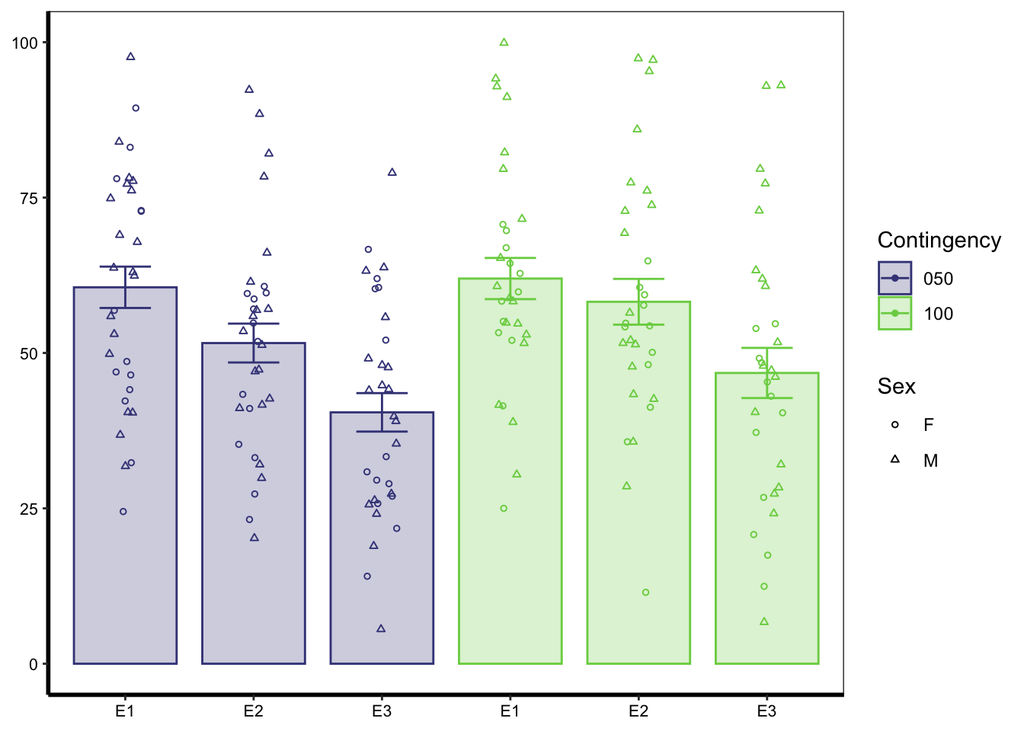

```r
Fig2.D2 <-
  ggplot(
  EXT_ave_2,
  aes(x=interaction(Exp_Type, Contingency),
      y=group_mean_freezing,
      group = Contingency,
      color = Contingency,
      fill = Contingency)) +
  scale_fill_viridis(discrete = TRUE, begin=0.2, end=0.8) +
  scale_colour_viridis(discrete = TRUE, begin=0.2, end=0.8) +
  geom_bar(stat = "identity", alpha=0.25, width = 0.8) +
  geom_errorbar(aes(ymin = group_mean_freezing-se, ymax = group_mean_freezing+se), width=0.4) +
  geom_point(
    data=EXT_id_2,
    aes(x=interaction(Exp_Type, Contingency), y=mean_freezing, shape=Sex),
    position = position_jitterdodge(jitter.height=0, jitter.width=0.25,
                                    dodge.width = 0.8),
    size=1) +
    scale_shape(solid = FALSE) +
  scale_x_discrete(limits=c("E1.050", "E2.050", "E3.050",
                            "E1.100", "E2.100", "E3.100"),
                   labels=c("E1", "E2", "E3", "E1", "E2", "E3")) +
  ylim(0,100) +
  labs(
    x = "CS Time",
    y = "% Time Freezing") +
  theme_bw() +
  theme(
        plot.background = element_blank(),
        plot.title = element_blank(),
        panel.grid.major = element_blank(),
        panel.grid.minor = element_blank(),
        axis.text.x = element_text(size = 8, color="black"),
        axis.text.y = element_text(size = 8, color="black"),
        axis.title.x = element_blank(),
        axis.title.y = element_blank(),
        axis.line.x = element_line(color="black", linewidth = 1),
        axis.line.y = element_line(color="black", linewidth = 1))
Fig2.D2
```

```r
#gsave("Fig2D2.pdf", plot = Fig2.D2, width = 1.5, height = 2, units = "in")
```

### D2 - Stats

```r
######## E1
m2d2 <- EXT_id_2 %>%
  aov_ez(id = "id",
         dv = "mean_freezing",
         between = "Contingency",
         within = c("Exp_Type"),
         data = .)
```

```
## Converting to factor: Contingency
```

```
## Contrasts set to contr.sum for the following variables: Contingency
```

```r
nice_m2d2 <- nice(m2d2)

kable(nice_m2d2, caption = '<b>Figure 2-D2: Between session FE Main FX</b>') %>%
  kable_styling(bootstrap_options = "striped", full_width = F, position = "left")
```

**Figure 2-D2: Between session FE Main FX**

| Effect | df | MSE | F | ges | p.value |
| --- | --- | --- | --- | --- | --- |
| Contingency | 1, 60 | 801.65 | 1.33 | .016 | .253 |
| Exp_Type | 1.92, 115.35 | 152.49 | 33.79 *** | .131 | <.001 |
| Contingency:Exp_Type | 1.92, 115.35 | 152.49 | 0.91 | .004 | .401 |

```r
#Post-hoc analyses
n1d2 <- emmeans(m2d2, ~ Exp_Type)

#Simple contrasts for Contingency X Bin
pairs_n1d2 <- pairs(n1d2, simple="each")

# By Bin
kable(pairs_n1d2[1], caption = '<b>Figure 2D: Simple Contrasts for FE session</b>')
```

**Figure 2D: Simple Contrasts for FE session**

| contrast | estimate | SE | df | t.ratio | p.value |
| --- | --- | --- | --- | --- | --- |
| E1 - E2 | 6.352998 | 2.056173 | 60 | 3.089720 | 0.0084092 |
| E1 - E3 | 17.654235 | 2.383991 | 60 | 7.405328 | 0.0000000 |
| E2 - E3 | 11.301237 | 2.070891 | 60 | 5.457187 | 0.0000029 |

## E. Extinction Recall ————————————————————-

Extinction recall was measured at recent (48 h) or remote (30 d) timepoints. Mice were returned to Context B and received a tone test (4 CS presentations) 48 hours and 30 days after the last day of extinction training. In addition to comparing experimental groups at each time point, we also compared percent time freezing within-subjects between the recent and remote time points to assess the level of spontaneous recovery, or the return of conditioned fear with the passage of time

### E - Dataframe

```r
ER_id_2 <- df %>%
  filter(str_detect(Component.Name, "pre-tone|post-tone", negate = TRUE),
         str_detect(CS_dur, "10"),
         str_detect(Trials, "6"),
         str_detect(Exp_Type, "ER")) %>%
  group_by(id, Sex, Contingency, Exp_Type) %>%
  summarize(mean_freezing=mean(Pct.Component.Time.Freezing), n=n(),
            se=sd(Pct.Component.Time.Freezing/sqrt(n())))
ER_ave_2 <- ER_id_2 %>%
  group_by(Contingency, Exp_Type) %>%
  summarize(group_mean_freezing=mean(mean_freezing), n=n(),
            se=sd(mean_freezing/sqrt(n())))
SR_id_2 <- df %>%
  filter(str_detect(Component.Name, "pre-tone|post-tone", negate = TRUE),
         str_detect(CS_dur, "10"),
         str_detect(Trials, "6"),
         str_detect(Exp_Type, "SR")) %>%
  group_by(id, Sex, Contingency, Exp_Type) %>%
  summarize(mean_freezing=mean(Pct.Component.Time.Freezing), n=n(),
            se=sd(Pct.Component.Time.Freezing/sqrt(n())))
SR_ave_2 <- SR_id_2 %>%
  group_by(Contingency, Exp_Type) %>%
  summarize(group_mean_freezing=mean(mean_freezing), n=n(),
            se=sd(mean_freezing/sqrt(n())))
ER_SR_id_2 <-rbind(ER_id_2, SR_id_2)
ER_SR_ave_2 <-rbind(ER_ave_2, SR_ave_2)
```

### E - Graph

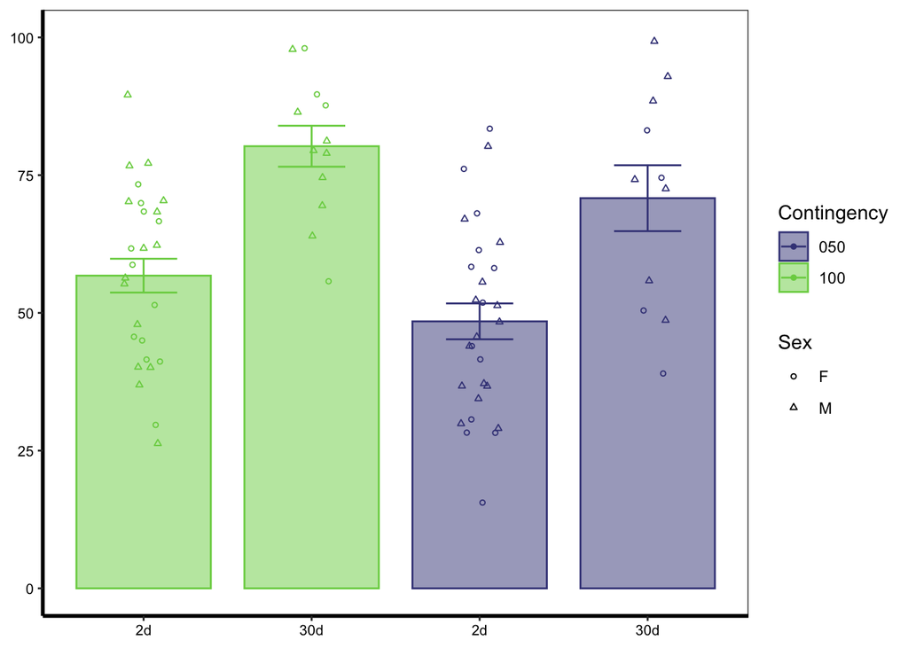

```r
Fig2F <-
  ggplot(
  ER_SR_ave_2,
  aes(x=interaction(Exp_Type, Contingency),
      y=group_mean_freezing,
      group = Contingency,
      color = Contingency,
      fill = Contingency)) +
  scale_fill_viridis(discrete = TRUE, begin=0.2, end=0.8) +
  scale_colour_viridis(discrete = TRUE, begin=0.2, end=0.8) +
  geom_bar(stat = "identity", alpha=0.5, width = 0.8) +
  geom_errorbar(aes(ymin = group_mean_freezing-se, ymax = group_mean_freezing+se), width=0.4) +
  geom_point(
    data=ER_SR_id_2,
    aes(x=interaction(Exp_Type, Contingency), y=mean_freezing, shape=Sex),
    position = position_jitterdodge(jitter.height=0, jitter.width=0.25,
                                    dodge.width = 0.8),
    size=1 ) +
  scale_shape(solid = FALSE) +
  scale_x_discrete(limits= c("ER.100", "SR.100", "ER.050", "SR.050"),
                  labels= c("2d", "30d", "2d", "30d")) +
  ylim(0,100) +
  labs(x = "Day", y = "% Time Freezing") +
  labs(
    x = "CS Time",
    y = "% Time Freezing") +
  theme_bw() +
  theme(
        plot.background = element_blank(),
        plot.title = element_blank(),
        panel.grid.major = element_blank(),
        panel.grid.minor = element_blank(),
        axis.text.x = element_text(size = 8, color="black"),
        axis.text.y = element_text(size = 8, color="black"),
        axis.title.x = element_blank(),
        axis.title.y = element_blank(),
        axis.line.x = element_line(color="black", linewidth = 1),
        axis.line.y = element_line(color="black", linewidth = 1))

Fig2F
```

```r
#ggsave("Fig2F.pdf", plot = Fig2F, width = 1.5, height = 2, units = "in")
```

### E - Stats

```r
m2e <- ER_SR_id_2 %>%
  aov_ez(id = "id",
         dv = "mean_freezing",
         between = "Contingency",
         within = "Exp_Type",
         data = .)
```

```
## Converting to factor: Contingency
```

```
## Contrasts set to contr.sum for the following variables: Contingency
```

```r
nice_m2e<- nice(m2e)

kable(nice_m2e, caption = '<b>Figure 2E: Main FX</b>') %>%
  kable_styling(bootstrap_options = "striped", full_width = F, position = "left")
```

**Figure 2E: Main FX**

| Effect | df | MSE | F | ges | p.value |
| --- | --- | --- | --- | --- | --- |
| Contingency | 1, 21 | 472.18 | 4.90 * | .149 | .038 |
| Exp_Type | 1, 21 | 154.83 | 52.01 *** | .379 | <.001 |
| Contingency:Exp_Type | 1, 21 | 154.83 | 1.68 | .019 | .209 |

```r
#Post-hoc analyses
#Contrast for Contingency
n2e.1 <- emmeans(m2e, ~ Contingency)
n2e.1_pairs<- pairs(n2e.1, simple="each")

kable(n2e.1_pairs[1], caption = '<b>Figure 2B-2: Simple contrasts for Contingency</b>')
```

**Figure 2B-2: Simple contrasts for Contingency**

| contrast | estimate | SE | df | t.ratio | p.value |
| --- | --- | --- | --- | --- | --- |
| Contingency050 - Contingency100 | -14.19697 | 6.413822 | 21 | -2.213496 | 0.0380669 |

```r
#Contrast for Recall test day
n2e.2 <- emmeans(m2e, ~ Exp_Type)
n2e.2_pairs<- pairs(n2e.2, simple="each")

kable(n2e.2_pairs[1], caption = '<b>Figure 2B-2: Simple contrasts for TT Day</b>')
```

**Figure 2B-2: Simple contrasts for TT Day**

| contrast | estimate | SE | df | t.ratio | p.value |
| --- | --- | --- | --- | --- | --- |
| ER - SR | -26.48727 | 3.672679 | 21 | -7.211976 | 4e-07 |

## END of Fig 2

```r
rm(list=(ls()))
```

# Fig 3. Lower US strength (0.3mA) & partial reinforcement alter fear learning but do not affect fear extinction.

The previous experiments failed to establish a PREE in fear learning in mice despite varying CS duration and the number of trials. One possible explanation for this was that the US strength used in previous protocols (0.75 mA) may have resulted in a ceiling effect, masking any effects of partial reinforcement on extinction. To avert this, we implemented a weaker US footshock (0.3 mA; Zweifel 2019). To further maximize the possibility to detect PREE we also widened the range of contingencies in our study by introducing a 10% contingency protocol (Fig. 3A, Scheuer 1969). Our experimental design incorporated three groups with varying contingencies: a consistent reinforcement group (a 100% contingency: 3CS:3US pairing) and two partial reinforcement groups: a 50% contingency (6CS:3US pairing) and a 10% contingency (30CS:3US). All statistical analyses and graphing were performed as in Fig. 1-2.

## Load and tidy data

Data was exported from VideoFreeze as CSV files. The header rows of the raw CSV files contain information regarding how the data was exported (ie how data was segmented into bins as well as what motion index threshold was used as a cut-off for assessing freezing).

```r
# Create a vector with each filename from all the CSVs in the home directory,
list.filenames <- list.files("./Fig3", pattern = ".csv$",
                             full.names=TRUE, recursive = TRUE)

# These vectors will be used to create 3CS binned averages
bin1 =c("tone 01", "tone 02", "tone 03")
bin2 =c("tone 04", "tone 05", "tone 06")
bin3 =c("tone 07", "tone 08", "tone 09")
bin4 =c("tone 10", "tone 11", "tone 12")

list.data <- list()

for (i in 1:length(list.filenames)) {
  list.data[[i]] <- read.csv(list.filenames[[i]], skip=
                               ifelse(str_detect(list.filenames[[i]], "FC\\w*10.csv$"), 42,
                                      ifelse(str_detect(list.filenames[[i]], "FC\\w*100.csv$"), 15,
                                             ifelse(str_detect(list.filenames[[i]], "FC\\w*50.csv$"), 18,
                                                          ifelse(str_detect(list.filenames[[i]], "ER"), 16,
                                                                 ifelse(str_detect(list.filenames[[i]], "SR"), 16,
                                                                        24)))))
  )

#Store the filename as a column since it contains experiment date and type
  list.data[[i]]$ExpDetails <- str_sub(list.filenames[[i]], 27, -5)

}

list.data <- list.data %>%
  reduce(full_join) %>%  #collapse separate items in list into one
  filter(Trial != "NA") %>% #remove empty rows
  separate(col=Animal, into = c("Strain", "Sex", "Cage", "Animal"), sep = "-") %>% # separate existing columns as indicated below
  separate(col=Group, into = c("CS_num", "Contingency", "CS_dur", "FE_context"), sep = "-") %>%
  separate(col=ExpDetails, into = c("Date", "Exp_Type", "Unused"), sep="_") %>%
  mutate(
    id = paste(Strain, Sex, Cage, Animal, sep="_"), #add a column with an animal ID
    CS= ifelse(str_detect(Exp_Type, "FC") & Contingency == "100", Component.Name,
         ifelse(str_detect(Exp_Type, "FC") & Contingency == "50" & Component.Name == "tone 01", "tone 01",
          ifelse(str_detect(Exp_Type, "FC") & Contingency == "50" & Component.Name == "tone 03", "tone 02",
           ifelse(str_detect(Exp_Type, "FC") & Contingency == "50" & Component.Name == "tone 06", "tone 03",

         ifelse(str_detect(Exp_Type, "FC") & Contingency == "10" & Component.Name == "tone 01", "tone 01",
            ifelse(str_detect(Exp_Type, "FC") & Contingency == "10" & Component.Name == "tone 23", "tone 02",
                ifelse(str_detect(Exp_Type, "FC") & Contingency == "10" & Component.Name == "tone 25", "tone 03",

                           ifelse(str_detect(Exp_Type, "FC", negate=TRUE), Component.Name, NA

                                           )))))))),

      Bin = ifelse(Component.Name %in% "pre-tone", "Pre",
                   ifelse(Component.Name %in% bin1, "1",
                         ifelse(Component.Name %in% bin2, "2",
                                ifelse(Component.Name %in% bin3, "3",
                                       ifelse(Component.Name %in% bin4, "4", "Post")))))
  )
```

[output not shown]

```r
df<-as.data.frame(list.data) %>% #Convert list into a dataframe
  relocate(20:25, .after = 12) %>%  #Move columns containing metadata such that they precede data
  filter(Trial != "NA")
#The code below removes animals whose freezing on FC2 was below 15% time freezing, this was done since the focus of the study is on extinction
 Remove <- df %>% #Create a dataframe  with only the animals whose FC2 freezing was below 15%
   filter(Exp_Type== "FC2") %>%
   group_by(id)%>%
   summarise(mean_FC2_freezing = mean(Pct.Component.Time.Freezing)) %>%
   filter(mean_FC2_freezing < 15)

 Remove <- unlist(Remove$id) #keep only the list of animals (as a vector)

 `%notin%` <- Negate(`%in%`) #Function for negating the %in% function (source: https://www.r-bloggers.com/2018/07/the-notin-operator/)

 df <- df %>%
   filter(id %notin% Remove) #filter for animals not in the Remove vector (i.e. filtering for animals freezing more than 15% on FC2)

rm(list=setdiff(ls(), "df")) #remove everything from environment except the df
```

## B. Within-session FC

Compare the average percent time freezing during CS presentations across the two days of FC training

### B1 - Dataframe

```r
#Create a dataframe with averages for each animal for each CS
FC_id_1.1 <- df %>%
  filter(str_detect(Exp_Type, "FC")) %>%
  group_by(id, Contingency, Sex, Component.Name, Exp_Type, CS) %>%
  summarize(mean_freezing=mean(Pct.Component.Time.Freezing), n=n())
```

```
## 'Component.Name', 'Exp_Type'. You can override using the `.groups` argument.
```

```r
#Create a dataframe with averages for each experimental group for each CS
FC_ave_1.1 <- FC_id_1.1 %>%
  group_by(Contingency,Component.Name, Exp_Type) %>%
  summarize(group_mean_freezing=mean(mean_freezing), n=n(),
            se=sd(mean_freezing/sqrt(n())))
```

### B1 - Graph

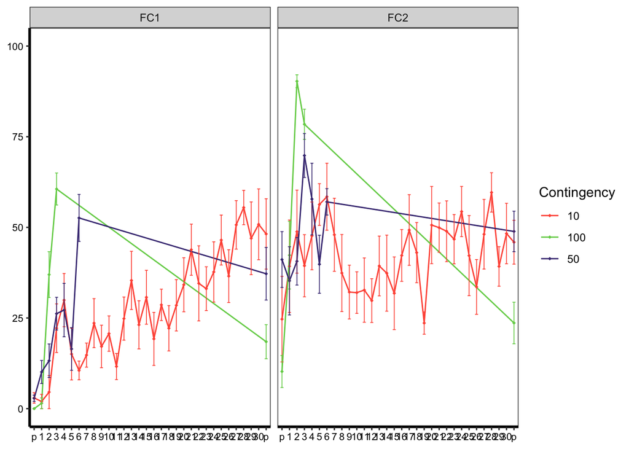

```r
Fig3.B1 <-
  ggplot(FC_ave_1.1, aes(x=interaction(Component.Name), y=group_mean_freezing, group=Contingency, color=Contingency)) +
  scale_color_manual(values = c("10" = "#FF5743",
                                "50" = "#453781FF",
                                "100" = "#73D055FF")) +
  facet_wrap(~Exp_Type) +
  geom_line() +
  geom_point(shape=18, size=1) +
  geom_errorbar(aes(ymin = group_mean_freezing-se, ymax = group_mean_freezing+se, width = 0.4), linewidth=0.3) +
  ylim(0,100) +
  scale_x_discrete(limits=c("pre-tone",
                            "tone 01", "tone 02", "tone 03",  "tone 04", "tone 05",
                            "tone 06", "tone 07", "tone 08",  "tone 09", "tone 10",
                            "tone 11", "tone 12", "tone 13",  "tone 14", "tone 15",
                            "tone 16", "tone 17", "tone 18",  "tone 19", "tone 20",
                            "tone 21", "tone 22", "tone 23",  "tone 24", "tone 25",
                            "tone 26", "tone 27", "tone 28",  "tone 29", "tone 30",
                            "post-tone"),
                   labels=c("p",
                            "1", "2", "3", "4", "5",
                            "6", "7", "8", "9", "10",
                            "11", "12", "13", "14", "15",
                            "16", "17", "18", "19", "20",
                            "21", "22", "23", "24", "25",
                            "26", "27", "28", "29", "30",
                            "p")) +
  labs(
    x = "CS Time",
    y = "% Time Freezing") +
  theme_bw() +
  theme(
        # legend.position = "none",
        # strip.background = element_blank(),
        # strip.text.x = element_blank(),
        plot.background = element_blank(),
        plot.title = element_blank(),
        panel.grid.major = element_blank(),
        panel.grid.minor = element_blank(),
        axis.text.x = element_text(size = 8, color="black"),
        axis.text.y = element_text(size = 8, color="black"),
        axis.title.x = element_blank(),
        axis.title.y = element_blank(),
        axis.line.x = element_line(color="black", linewidth = 1),
        axis.line.y = element_line(color="black", linewidth = 1))

Fig3.B1
```

```r
 # ggsave("Fig3B1.pdf", plot = Fig3.B1, width = 3, height = 2, units = "in")
```

### B1 - Stats

```r
# Analysis of FC1 Data
m3b1_FC1 <- FC_id_1.1  %>%
   filter(str_detect(CS, "tone 01|tone 02|tone 03") &
          Exp_Type == "FC1")  %>%
  aov_ez(id = "id",
         dv = "mean_freezing",
         between = c("Contingency"),
         within = c("CS"),
         data = .)
```

```
## Converting to factor: Contingency
```

```
## Contrasts set to contr.sum for the following variables: Contingency
```

```r
#ANOVA table
nice_m3b1_FC1 <-nice(m3b1_FC1)
kable(nice_m3b1_FC1, caption = '<b>Figure 3.B1: Main FX within-session FC1</b>') %>%
  kable_styling(bootstrap_options = "striped", full_width = F, position = "left")
```

**Figure 3.B1: Main FX within-session FC1**

| Effect | df | MSE | F | ges | p.value |
| --- | --- | --- | --- | --- | --- |
| Contingency | 2, 21 | 215.16 | 0.95 | .032 | .401 |
| CS | 1.90, 39.94 | 198.18 | 75.96 *** | .697 | <.001 |
| Contingency:CS | 3.80, 39.94 | 198.18 | 1.64 | .091 | .185 |

```r
#Post-hoc analyses
n3b1.1_FC1 <- emmeans(m3b1_FC1, ~ CS)
n3b1.1_pairs_FC1<- pairs(n3b1.1_FC1, simple="each")
kable(n3b1.1_pairs_FC1[1], caption = '<b>Figure 3.B1: Simple contrasts for CS</b>')
```

**Figure 3.B1: Simple contrasts for CS**

| contrast | estimate | SE | df | t.ratio | p.value |
| --- | --- | --- | --- | --- | --- |
| tone.01 - tone.02 | -27.56125 | 3.567046 | 21 | -7.726632 | 0.0000004 |
| tone.01 - tone.03 | -48.70458 | 3.936247 | 21 | -12.373356 | 0.0000000 |
| tone.02 - tone.03 | -21.14333 | 4.346757 | 21 | -4.864162 | 0.0002347 |

```r
#######################
# Analysis of FC2 Data
m3b1_FC2 <- FC_id_1.1  %>%
   filter(str_detect(CS, "tone 01|tone 02|tone 03") &
          Exp_Type == "FC2") %>%
  aov_ez(id = "id",
         dv = "mean_freezing",
         between = c("Contingency"),
         within = c("CS"),
         data = .)
```

```
## Converting to factor: Contingency
## Contrasts set to contr.sum for the following variables: Contingency
```

```r
#ANOVA table
nice_m3b1_FC2 <-nice(m3b1_FC2)
kable(nice_m3b1_FC2, caption = '<b>Figure 1.B1: Main FX within-session FC2</b>') %>%
  kable_styling(bootstrap_options = "striped", full_width = F, position = "left")
```

**Figure 1.B1: Main FX within-session FC2**

| Effect | df | MSE | F | ges | p.value |
| --- | --- | --- | --- | --- | --- |
| Contingency | 2, 21 | 801.85 | 5.77 * | .223 | .010 |
| CS | 1.72, 36.08 | 428.60 | 15.27 *** | .258 | <.001 |
| Contingency:CS | 3.44, 36.08 | 428.60 | 2.62 + | .107 | .059 |

```r
#Post-hoc analyses
#Contrast for CS
n3b1.1_FC2 <- emmeans(m3b1_FC2, ~ CS * Contingency)
n3b1.1_pairs_FC2<- pairs(n3b1.1_FC2, simple="each")

kable(n3b1.1_pairs_FC2[1], caption = '<b>Figure 1.B1: Simple contrasts for CS</b>')
```

**Figure 1.B1: Simple contrasts for CS**

| contrast | Contingency | estimate | SE | df | t.ratio | p.value |
| --- | --- | --- | --- | --- | --- | --- |
| tone.01 - tone.02 | 10 | -7.46875 | 10.752951 | 21 | -0.6945768 | 0.7692126 |
| tone.01 - tone.03 | 10 | -2.93500 | 10.260570 | 21 | -0.2860465 | 0.9559917 |
| tone.02 - tone.03 | 10 | 4.53375 | 7.433416 | 21 | 0.6099148 | 0.8163224 |
| tone.01 - tone.02 | 100 | -47.98125 | 10.752951 | 21 | -4.4621474 | 0.0006056 |
| tone.01 - tone.03 | 100 | -36.11375 | 10.260570 | 21 | -3.5196632 | 0.0055344 |
| tone.02 - tone.03 | 100 | 11.86750 | 7.433416 | 21 | 1.5965070 | 0.2691186 |
| tone.01 - tone.02 | 50 | -34.56625 | 10.752951 | 21 | -3.2145828 | 0.0111145 |
| tone.01 - tone.03 | 50 | -21.78125 | 10.260570 | 21 | -2.1228110 | 0.1092714 |
| tone.02 - tone.03 | 50 | 12.78500 | 7.433416 | 21 | 1.7199361 | 0.2213593 |

```r
kable(n3b1.1_pairs_FC2[2], caption = '<b>Figure 1.B1: Simple contrasts for Contingency</b>')
```

**Figure 1.B1: Simple contrasts for Contingency**

| contrast | CS | estimate | SE | df | t.ratio | p.value |
| --- | --- | --- | --- | --- | --- | --- |
| Contingency10 - Contingency100 | tone.01 | -3.05375 | 15.014836 | 21 | -0.2033822 | 0.9774790 |
| Contingency10 - Contingency50 | tone.01 | 4.01375 | 15.014836 | 21 | 0.2673189 | 0.9614455 |
| Contingency100 - Contingency50 | tone.01 | 7.06750 | 15.014836 | 21 | 0.4707011 | 0.8856919 |
| Contingency10 - Contingency100 | tone.02 | -43.56625 | 7.577658 | 21 | -5.7493028 | 0.0000301 |
| Contingency10 - Contingency50 | tone.02 | -23.08375 | 7.577658 | 21 | -3.0462909 | 0.0162030 |
| Contingency100 - Contingency50 | tone.02 | 20.48250 | 7.577658 | 21 | 2.7030120 | 0.0341638 |
| Contingency10 - Contingency100 | tone.03 | -36.23250 | 10.084838 | 21 | -3.5927698 | 0.0046729 |
| Contingency10 - Contingency50 | tone.03 | -14.83250 | 10.084838 | 21 | -1.4707723 | 0.3246728 |
| Contingency100 - Contingency50 | tone.03 | 21.40000 | 10.084838 | 21 | 2.1219975 | 0.1094377 |

## B2 - Between-session FC

### B2 - Dataframe

```r
#Create a dataframe with CS freezing averaged for each experimental group
FC_id_1.2 <- FC_id_1.1 %>%
  filter(str_detect(Component.Name, "pre-tone|post-tone", negate=TRUE)) %>%
  group_by(id, Sex, Contingency, Exp_Type) %>%
  summarize(mean_freezing=mean(mean_freezing), n=n(),
            se=sd(mean_freezing/sqrt(n())))
FC_ave_1.2 <- FC_id_1.2 %>%
  group_by(Contingency, Exp_Type) %>%
  summarize(group_mean_freezing=mean(mean_freezing), n=n(),
            se=sd(mean_freezing/sqrt(n())))
```

### B2 - Graph

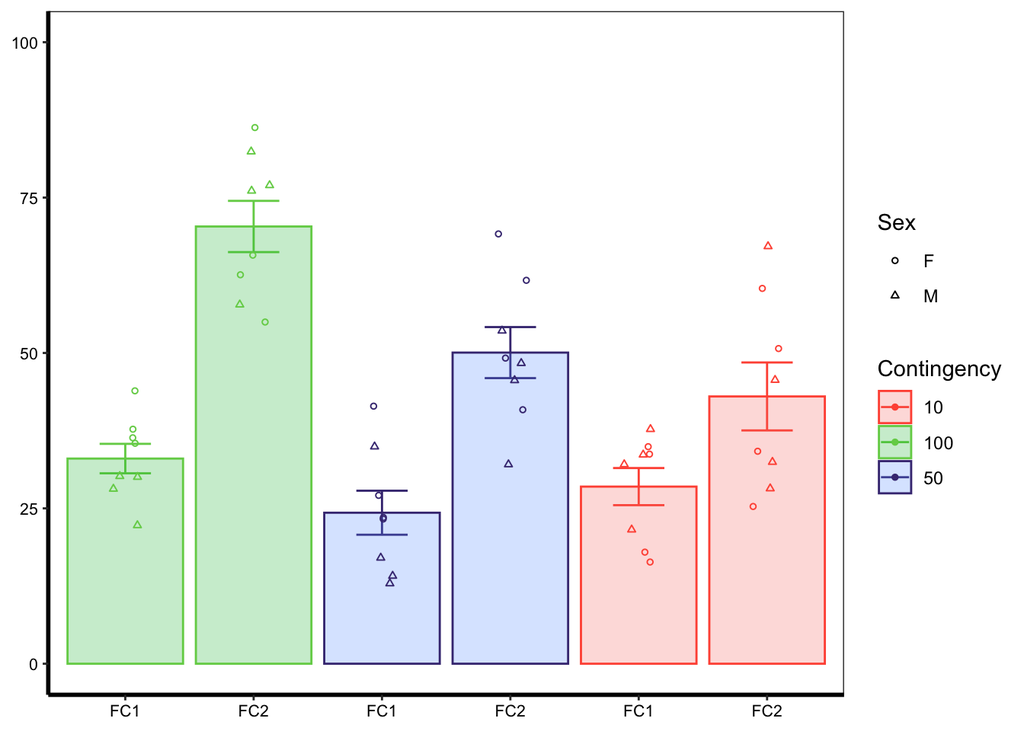

```r
Fig3.B2 <- ggplot(FC_ave_1.2,
  aes(x=interaction(Exp_Type,Contingency),
      y=group_mean_freezing,
      group = Contingency, fill= Contingency, color=Contingency)) +
  scale_color_manual(values = c("10" = "#FF5743",
                                "50" = "#453781FF",
                                "100" = "#73D055FF")) +
  geom_errorbar(aes(ymin = group_mean_freezing-se, ymax = group_mean_freezing+se), width=0.4) +
  geom_bar(stat="identity", alpha=0.25) +
  geom_point(
    data=FC_id_1.2,
    aes(x=interaction(Exp_Type, Contingency), y=mean_freezing, shape=Sex),position = position_jitterdodge(jitter.height=0, jitter.width=0.25, dodge.width = 0.8), size=1) +
  scale_shape(solid = FALSE) +
   scale_x_discrete(limits=c("FC1.100","FC2.100", "FC1.50", "FC2.50", "FC1.10", "FC2.10"),
                    labels= c("FC1", "FC2", "FC1", "FC2", "FC1", "FC2")) +
  ylim(0,100) +
  theme_bw() +
  theme(
        # legend.position = "none",
        # strip.background = element_blank(),
        # strip.text = element_blank(),
        plot.background = element_blank(),
        axis.title.x = element_blank(),
        axis.title.y = element_blank(),
        plot.title = element_blank(),
        panel.grid.major = element_blank(),
        panel.grid.minor = element_blank(),
        axis.text.x = element_text(size = 8, color="black"),
        axis.text.y = element_text(size = 8, color="black"),
        axis.line.x = element_line(color="black", linewidth = 1),
        axis.line.y = element_line(color="black", linewidth = 1))+
  labs(
    x = "CS Time",
    y = "% Time Freezing")

Fig3.B2
```

```r
  #ggsave("Fig3B2.pdf", plot = Fig3.B2, width = 1, height = 2, units = "in")
```

### B2 - Stats

```r
m3b2 <- FC_id_1.2 %>%
  aov_ez(id = "id",
         dv = "mean_freezing",
         between = c("Contingency"),
         within = c("Exp_Type"),
         data = .)
```

```
## Converting to factor: Contingency
```

```
## Contrasts set to contr.sum for the following variables: Contingency
```

```r
#ANOVA table
nice_m3b2  <-nice(m3b2)
kable(nice_m3b2, caption = '<b>Figure 3.B2: Main FX between-sessions FC</b>') %>%
  kable_styling(bootstrap_options = "striped", full_width = F, position = "left")
```

**Figure 3.B2: Main FX between-sessions FC**

| Effect | df | MSE | F | ges | p.value |
| --- | --- | --- | --- | --- | --- |
| Contingency | 2, 21 | 146.92 | 8.46 ** | .328 | .002 |
| Exp_Type | 1, 21 | 95.23 | 84.34 *** | .612 | <.001 |
| Contingency:Exp_Type | 2, 21 | 95.23 | 5.47 * | .170 | .012 |

```r
#Post-hoc analyses
n3b2 <- emmeans(m3b2, ~ Contingency * Exp_Type)
n3b2_pairs<- pairs(n3b2, simple="each")
kable(n3b2_pairs[1], caption = '<b>Figure 3.B2: Simple contrasts for Contingency</b>')
```

**Figure 3.B2: Simple contrasts for Contingency**

| contrast | Exp_Type | estimate | SE | df | t.ratio | p.value |
| --- | --- | --- | --- | --- | --- | --- |
| Contingency10 - Contingency100 | FC1 | -4.511833 | 4.248125 | 21 | -1.0620763 | 0.5473008 |
| Contingency10 - Contingency50 | FC1 | 4.201917 | 4.248125 | 21 | 0.9891226 | 0.5916074 |
| Contingency100 - Contingency50 | FC1 | 8.713750 | 4.248125 | 21 | 2.0511989 | 0.1247483 |
| Contingency10 - Contingency100 | FC2 | -27.344750 | 6.518412 | 21 | -4.1950017 | 0.0011383 |
| Contingency10 - Contingency50 | FC2 | -7.055583 | 6.518412 | 21 | -1.0824083 | 0.5350890 |
| Contingency100 - Contingency50 | FC2 | 20.289167 | 6.518412 | 21 | 3.1125934 | 0.0139776 |

```r
kable(n3b2_pairs[2], caption = '<b>Figure 3.B2: Simple contrasts for FC Day</b>')
```

**Figure 3.B2: Simple contrasts for FC Day**

| contrast | Contingency | estimate | SE | df | t.ratio | p.value |
| --- | --- | --- | --- | --- | --- | --- |
| FC1 - FC2 | 10 | -14.50708 | 4.879259 | 21 | -2.973214 | 0.0072520 |
| FC1 - FC2 | 100 | -37.34000 | 4.879259 | 21 | -7.652801 | 0.0000002 |
| FC1 - FC2 | 50 | -25.76458 | 4.879259 | 21 | -5.280429 | 0.0000310 |

## C. FC Recall ———————————————————-

Retrieval was evaluated as the proportion of time freezing between two CS epochs: (1) CS freezing on FC Day 2 and (2) the first four CS presentations on Extinction Day 1.

### C - Dataframe

```r
E1_Session1_id_1 <- df %>%
  filter(str_detect(Exp_Type, "E1"),
         str_detect(Exp_Type, "ER", negate = TRUE),
         str_detect(Component.Name,  "tone 01|tone 02|tone 03|tone 04")) %>%
  group_by(id, Contingency, Exp_Type, Sex) %>%
  summarize(mean_freezing=mean(Pct.Component.Time.Freezing), n=n(),
            se=sd(Pct.Component.Time.Freezing/sqrt(n())))
E1_Session1_ave_1 <- E1_Session1_id_1 %>%
  group_by(Contingency, Exp_Type) %>%
  summarize(group_mean_freezing=mean(mean_freezing), n=n(),
            se=sd(mean_freezing/sqrt(n())))
FC2_id_1 <- df %>%
  filter(str_detect(Component.Name, "pre-tone|post-tone", negate = TRUE),
         str_detect(Exp_Type, "FC2")) %>%
  group_by(id, Contingency, Exp_Type, Sex) %>%
  summarize(mean_freezing=mean(Pct.Component.Time.Freezing), n=n(),
            se=sd(Pct.Component.Time.Freezing/sqrt(n())))
FC2_ave_1 <- FC2_id_1 %>%
  group_by(Contingency, Exp_Type) %>%
  summarize(group_mean_freezing=mean(mean_freezing), n=n(),
            se=sd(mean_freezing/sqrt(n())))
E1_FC2_id_1 <-rbind(E1_Session1_id_1, FC2_id_1)

E1_FC2_ave_1 <-rbind(E1_Session1_ave_1, FC2_ave_1)
```

### C - Graph

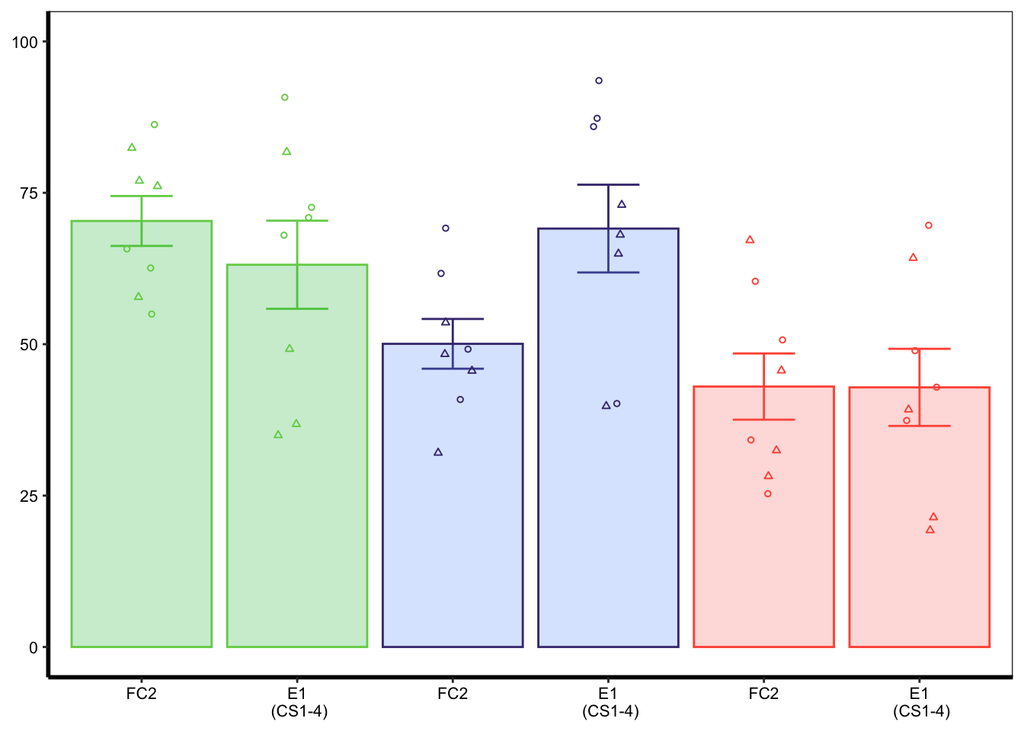

```r
Fig3C <- ggplot(
  E1_FC2_ave_1,
  aes(x=interaction(Exp_Type,Contingency),
      y=group_mean_freezing,
      group = Contingency, fill= Contingency, color=Contingency)) +
  scale_color_manual(values = c("10" = "#FF5743",
                                "50" = "#453781FF",
                                "100" = "#73D055FF")) +
  geom_errorbar(aes(ymin = group_mean_freezing-se, ymax = group_mean_freezing+se), width=0.4) +
  geom_bar(stat="identity", alpha=0.25) +
  geom_point(
    data=E1_FC2_id_1,
    aes(x=interaction(Exp_Type, Contingency), y=mean_freezing, shape=Sex),position = position_jitterdodge(jitter.height=0, jitter.width=0.25, dodge.width = 0.8), size=1) +
  scale_shape(solid = FALSE) +
   scale_x_discrete(limits=c("FC2.100", "E1.100", "FC2.50", "E1.50", "FC2.10", "E1.10"),
                    labels= c("FC2", "E1\n (CS1-4)", "FC2", "E1\n (CS1-4)", "FC2", "E1\n (CS1-4)")) +
  ylim(0,100) +
  theme_bw() +
  theme(
        legend.position = "none",
        strip.background = element_blank(),
        strip.text = element_blank(),
        plot.background = element_blank(),
        axis.title.x = element_blank(),
        axis.title.y = element_blank(),
        plot.title = element_blank(),
        panel.grid.major = element_blank(),
        panel.grid.minor = element_blank(),
        axis.text.x = element_text(size = 8, color="black"),
        axis.text.y = element_text(size = 8, color="black"),
        axis.line.x = element_line(color="black", linewidth = 1),
        axis.line.y = element_line(color="black", linewidth = 1))+
  labs(
    x = "CS Time",
    y = "% Time Freezing")

Fig3C
```

```r
# ggsave("Fig3C.pdf", plot = Fig3C, width = 2, height = 2, units = "in")
```

### C - Stats

```r
m3c <- E1_FC2_id_1 %>%
  aov_ez(id = "id",
         dv = "mean_freezing",
         between = c("Contingency"),
         within = "Exp_Type",
         data = .)
```

```
## Converting to factor: Contingency
```

```
## Contrasts set to contr.sum for the following variables: Contingency
```

```r
#ANOVA table
nice_m3c <-nice(m3c)
kable(nice_m3c, caption = '<b>Figure 3C: Main FX FC Recall</b>') %>%
  kable_styling(bootstrap_options = "striped", full_width = F, position = "left", font_size = 14)
```

**Figure 3C: Main FX FC Recall**

| Effect | df | MSE | F | ges | p.value |
| --- | --- | --- | --- | --- | --- |
| Contingency | 2, 21 | 361.13 | 6.60 ** | .289 | .006 |
| Exp_Type | 1, 21 | 198.15 | 0.92 | .015 | .349 |
| Contingency:Exp_Type | 2, 21 | 198.15 | 3.73 * | .112 | .041 |

```r
#Post-hoc analyses
n3c <- emmeans(m3c, ~ Contingency * Exp_Type)

#Contrast for CS x FC Day interaction
n3c_pairs<- pairs(n3c, simple="each")
kable(n3c_pairs[1], caption = '<b>Figure 3.C: Simple contrasts for Contingency</b>')
```

**Figure 3.C: Simple contrasts for Contingency**

| contrast | Exp_Type | estimate | SE | df | t.ratio | p.value |
| --- | --- | --- | --- | --- | --- | --- |
| Contingency10 - Contingency100 | E1 | -20.249063 | 9.865705 | 21 | -2.0524699 | 0.1244584 |
| Contingency10 - Contingency50 | E1 | -26.220938 | 9.865705 | 21 | -2.6577865 | 0.0375887 |
| Contingency100 - Contingency50 | E1 | -5.971875 | 9.865705 | 21 | -0.6053166 | 0.8187892 |
| Contingency10 - Contingency100 | FC2 | -27.344750 | 6.518412 | 21 | -4.1950017 | 0.0011383 |
| Contingency10 - Contingency50 | FC2 | -7.055583 | 6.518412 | 21 | -1.0824083 | 0.5350890 |
| Contingency100 - Contingency50 | FC2 | 20.289167 | 6.518412 | 21 | 3.1125934 | 0.0139776 |

```r
kable(n3c_pairs[2], caption = '<b>Figure 3.C: Simple contrasts for CS Epoch</b>')
```

**Figure 3.C: Simple contrasts for CS Epoch**

| contrast | Contingency | estimate | SE | df | t.ratio | p.value |
| --- | --- | --- | --- | --- | --- | --- |
| E1 - FC2 | 10 | -0.1344167 | 7.038335 | 21 | -0.0190978 | 0.9849434 |
| E1 - FC2 | 100 | -7.2301042 | 7.038335 | 21 | -1.0272464 | 0.3159921 |
| E1 - FC2 | 50 | 19.0309375 | 7.038335 | 21 | 2.7038978 | 0.0132945 |

## D. Extinction acquisition———————————————–

### D1 - Within-session FE

To evaluate the effect of partial reinforcement on fear extinction acquisition, mice were exposed to 12 unreinforced CS presentations for three consecutive days (E1, E2, E3) in a novel context (Context B). Percent time freezing was averaged in bins composed of 3CS presentations.

### D1 - Dataframe

```r
EXT_bin_id_1 <- df %>%
  filter(str_detect(Exp_Type, "E"),
         str_detect(Experiment, "ER", negate = TRUE)) %>%
  group_by(Exp_Type, id, Sex, Contingency, Bin) %>%
  summarize(mean_freezing=mean(Pct.Component.Time.Freezing), n=n(),
            se=sd(Pct.Component.Time.Freezing/sqrt(n())))
```

```
## can override using the `.groups` argument.
```

```r
EXT_bin_ave_1 <- EXT_bin_id_1 %>%
  group_by(Exp_Type, Bin, Contingency) %>%
  summarize(group_mean_freezing=mean(mean_freezing), n=n(),
            se=sd(mean_freezing/sqrt(n())))
EXT_bin_ave_1$Bin <- factor(EXT_bin_ave_1$Bin, levels = c("Pre", "1", "2", "3", "4", "Post"))
```

### D1 - Graph

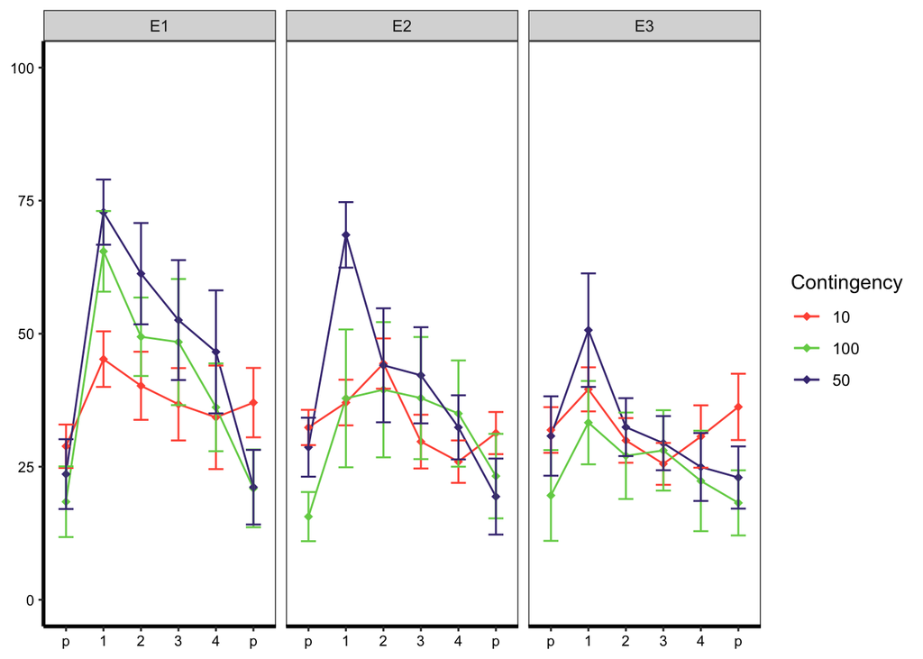

```r
Fig3D.1 <-
  ggplot(
  data = subset(EXT_bin_ave_1, !is.na(Bin)),
  aes(x=interaction(Bin),
      y=group_mean_freezing,
      group = Contingency, color= Contingency, fill=Contingency)) +
  scale_color_manual(values = c("10" = "#FF5743",
                                "50" = "#453781FF",
                                "100" = "#73D055FF")) +
  facet_wrap(~Exp_Type) +
  geom_line() +
  geom_point(shape=18, size=2) +
  scale_shape(solid = FALSE) +
  geom_errorbar(aes(ymin = group_mean_freezing-se, ymax = group_mean_freezing+se), width=0.4) +
  scale_x_discrete(limits=c("Pre", "1", "2", "3", "4", "Post"),
                   labels=c("p", "1", "2", "3", "4", "p")) +
  ylim(0,100) +
  labs(x = "Bin", y = "% Time Freezing") +
  theme_bw() +
   theme(
        # legend.position = "none",
        # strip.background = element_blank(),
        # strip.text = element_blank(),
        plot.background = element_blank(),
        plot.title = element_blank(),
        panel.grid.major = element_blank(),
        panel.grid.minor = element_blank(),
        axis.text.x = element_text(size = 8, color="black"),
        axis.text.y = element_text(size = 8, color="black"),
        axis.title.x = element_blank(),
        axis.title.y = element_blank(),
        axis.line.x = element_line(color="black", linewidth = 1),
        axis.line.y = element_line(color="black", linewidth = 1))

Fig3D.1
```

```r
#ggsave("Fig3D1.pdf", plot = Fig3D.1, width = 2.5, height = 2, units = "in")
```